# M2.891_20251_PEC2_Jsolanm

[figure not shown]

M2.891 · Aprendizaje automático · PEC2

2025-1 · Máster universitario en Ciencia de datos (Data science)

Estudios de Informática, Multimedia y Telecomunicación

# PEC 2: Métodos no supervisados

En esta práctica exploraremos el **aprendizaje no supervisado** con un caso real: el análisis y agrupamiento de miles de recetas. A partir de datos textuales y de ingredientes, crearemos distintas representaciones (desde *embeddings* semánticos de modelos de lenguaje hasta vectores *one-hot*) para descubrir patrones sin etiquetas. Usaremos **UMAP** para reducir dimensionalidad y distintas técnicas de *clustering* para segmentar, observando cómo la elección de representación y métrica de distancia condiciona las estructuras detectadas y su interpretación.

La PEC consta de dos ejercicios:

- **Clustering con distintas estrategias**: k-means y regla del codo, basadas en densidad y jerárquicas.
- **Aplicación**: clustering y reducción de dimensionalidad culinaria, distintas maneras de descubrir grupos de recetas en base a sus metadatos.

**Importante**: cada uno de los ejercicios puede suponer varios minutos de ejecución, por lo que la entrega debe hacerse en formato notebook y en formato html, donde se vea el código, los resultados y comentarios de cada ejercicio. Se puede exportar el notebook a html desde el menú File → Download as → HTML.

**Importante**: existe un tipo de celda especial para albergar texto. Este tipo de celda os será muy útil para responder a las diferentes preguntas teóricas planteadas a lo largo de cada PEC. Para cambiar el tipo de celda a este tipo, elegid en el menú: Cell → Cell Type → Markdown.

**Importante**: la solución planteada no debe utilizar métodos, funciones o parámetros declarados "deprecated" en futuras versiones.

**Importante**: es conveniente que utilicéis una semilla con un valor fijo (en este Notebook se os propone la variable seed inicializada a 100) en todos aquellos métodos o funciones que contengan alguna componente aleatoria para aseguraros de que obtendréis siempre el mismo resultado en las distintas ejecuciones de vuestro código.

**Importante**: si la ejecución de una celda toma más de 20 minutos puedes reducir el número de filas del dataframe para agilizar el proceso.

**Importante**: no olvidéis poner vuestro nombre y apellidos en la siguiente celda.

**Nombre y apellidos:** Jorge Solán Morote

Para ello vamos a necesitar las siguientes librerías:

```python
import ast
from collections import Counter
import random

import hdbscan
import matplotlib
import matplotlib.pyplot as plt
import numpy as np
import pandas as pd
from scipy.spatial.distance import pdist, squareform, cdist
from scipy.cluster.hierarchy import linkage, dendrogram, fcluster
from sentence_transformers import SentenceTransformer
from sklearn import cluster
from sklearn.cluster import KMeans, DBSCAN, MeanShift, estimate_bandwidth, AgglomerativeClustering
from sklearn import datasets
from sklearn import manifold
from sklearn.metrics import silhouette_score, pairwise_distances
from sklearn.metrics.pairwise import cosine_distances, euclidean_distances
from sklearn.preprocessing import MultiLabelBinarizer, normalize
import tqdm
import re
import umap.umap_ as umap
```

```python
seed = 100
```

## 1. Métodos de *clustering* (4 puntos)

Este ejercicio trata de explorar distintas técnicas de agrupamiento ajustándolas a distintos conjuntos de datos.

El objetivo es doble: entender la influencia de los parámetros en su comportamiento, y conocer sus limitaciones en la búsqueda de estructuras de datos.

### Generación de los conjuntos de datos

```python
X_blobs, y_blobs = datasets.make_blobs(n_samples=1000, n_features=2, centers=4, cluster_std=1.6, random_state=seed)
X_moons, y_moons = datasets.make_moons(n_samples=1000, noise=.07, random_state=seed)
X_circles, y_circles = datasets.make_circles(n_samples=1000, factor=.5, noise=.05, random_state=seed)
```

Cada dataset tiene 2 variables: una variable *X* que contiene 2 features (columnas) y tantas filas como muestras. Y una variable *y* que alberga las etiquetas que identifican cada cluster.

A lo largo del ejercicio no se usará la variable *y* (sólo con el objetivo de visualizar). El objetivo es a través de los distintos modelos de *clustering* conseguir encontrar las estructuras descritas por las variables *y*.

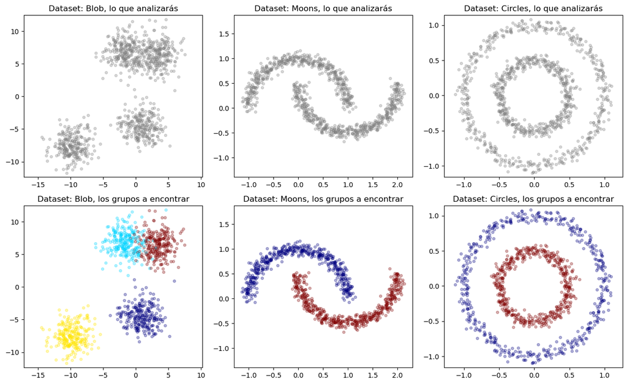

```python
fig, axis = plt.subplots(2, 3, figsize=(13, 8))
for i, (X, y, ax, name) in enumerate(zip([X_blobs, X_moons, X_circles] * 2,
                                         [None] * 3 + [y_blobs, y_moons, y_circles],
                                         axis.reshape(-1),
                                         ['Blob', 'Moons', 'Circles'] * 2)):
    ax.set_title('Dataset: {}, '.format(name) + ('lo que analizarás' if i < 3 else 'los grupos a encontrar'))
    if y is not None:
        ax.scatter(X[:,0], X[:,1], s=15, c=y, alpha=.3, cmap='jet')
    else:
        ax.scatter(X[:,0], X[:,1], s=15, c='gray', alpha=.3, cmap='jet')
    ax.axis('equal')
plt.tight_layout()
```

### 1 a. K-means

En este apartado se pide probar el algoritmo *k-means* sobre los tres datasets presentados anteriormente ajustando con los parámetros adecuados y analizar sus resultados.

```python
X, y = X_blobs, y_blobs
```

Para estimar el número de clusters a detectar por *k-means*. Una técnica para estimar $k$ es, como se explica en la teoría:

> Los criterios anteriores (minimización de distancias intra grupo o maximización de distancias inter grupo) pueden usarse para establecer un valor adecuado para el parámetro k. Valores k para los que ya no se consiguen mejoras significativas en la homogeneidad interna de los segmentos o la heterogeneidad entre segmentos distintos, deberían descartarse.

Lo que popularmente se conocer como *regla del codo*.

Primero es necesario calcular la suma de los errores cuadráticos ([*SSE*](https://bl.ocks.org/rpgove/0060ff3b656618e9136b)) que consiste en la suma de todos los errores (distancia de cada punto a su centroide asignado) al cuadrado.

$$SSE = \sum_{i=1}^{K} \sum_{x \in C_i} euclidean(x, c_i)^2$$

Donde $K$ es el número de clusters a buscar por *k-means*, $x \in C_i$ son los puntos que pertenecen a i-ésimo cluster, $c_i$ es el centroide del cluster $C_i$ (al que pertenece el punto $x$), y $euclidean$ es la [distancia euclídea](https://en.wikipedia.org/wiki/Euclidean_distance).

Este procedimiento realizado para cada posible valor $k$, resulta en una función monótona decreciente, donde el eje $x$ representa los distintos valores de $k$, y el eje $y$ el $SSE$. Intuitivamente se podrá observar un significativo descenso del error, que indicará el valor idóneo de $k$.

**Se pide realizar la representación gráfica de la regla del codo junto a su interpretación, utilizando la librería `matplotlib` y la implementación en scikit-learn de [*k-means*](http://scikit-learn.org/stable/modules/generated/sklearn.cluster.KMeans.html).**

```python
def codo_kmean(X):
    sse = []
    k_values = range(1, 11)

    for k in k_values:
        kmeans = KMeans(n_clusters=k, random_state=seed, n_init="auto")
        kmeans.fit(X)
        sse.append(kmeans.inertia_)  # inertia_ = suma de errores cuadráticos (SSE)

    # Visualización regla del codo
    plt.figure(figsize=(8, 5))
    plt.plot(k_values, sse, marker='o')
    plt.xlabel("Número de clusters (k)")
    plt.ylabel("Suma de errores cuadráticos (SSE)")
    plt.title("Método del codo para estimar k óptimo")
    plt.grid(True)
    plt.show()

def visualization_kmean(X, k_cluster):
    kmeans = KMeans(n_clusters=k_cluster, random_state=seed, n_init="auto")
    labels = kmeans.fit_predict(X)
    # Visualización de los grupos
    plt.figure(figsize=(8, 6))
    plt.scatter(X[:, 0], X[:, 1], c=labels, cmap='viridis', s=40, alpha=0.7, edgecolor='k')
    plt.scatter(kmeans.cluster_centers_[:, 0], kmeans.cluster_centers_[:, 1],
                c='red', marker='X', s=40, label='Centroides')
    plt.title(f"K-Means con k={k_cluster}")
    plt.xlabel("Componente 1")
    plt.ylabel("Componente 2")
    plt.legend()
    plt.grid(True)
    plt.show()
```

**Implementación:** Cálculo y visualización de la regla del codo en el dataset Blobs.

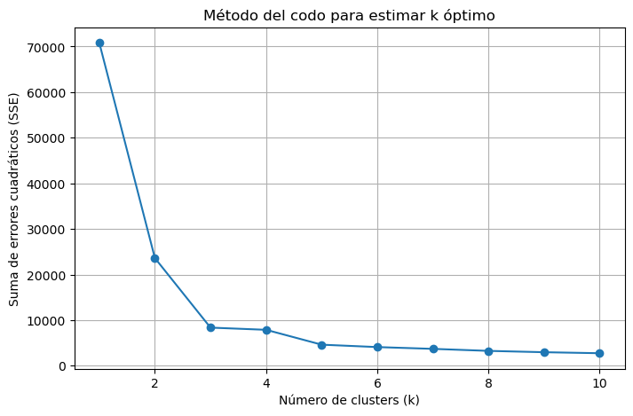

```python
codo_kmean(X)
```

**Análisis:** ¿Qué se interpreta en la gráfica? ¿Cómo podría mejorarse la elección de $k$?.

En la gráfica vemos la representación de la suma de los errores cuadráticos(SSE) según el número de clusters escogidos. He creado una pequeña prueba para mirar entre 1 y 10 clusters. Vemos que, a partir de 3 clusters la reducción del valor de la SSE no es tan notoria, con un ligero salto también con el valor de 5, lo que sugiere que k=3 o k=5 son valores óptimos para este dataset.

Para validar esta elección, se podrían usar métricas complementarias como el Silhouette Score (mide la cohesión intra-cluster) o el método de Gap Statistic.

**Implementación:** Cálculo y visualización de los grupos en el dataset Blobs.

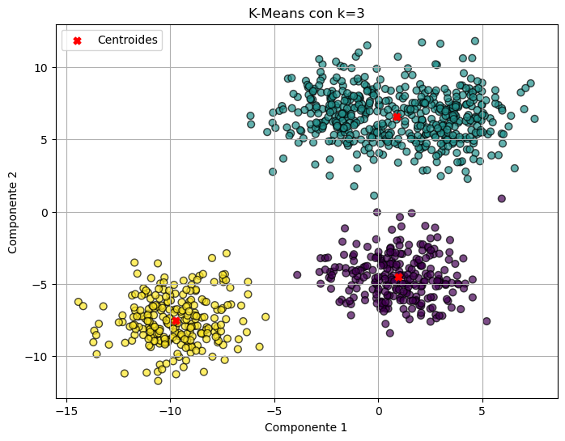

```python
visualization_kmean(X, 3)
```

**Análisis:** ¿Qué ha sucedido? Explica los motivos por los que crees que se ha producido ese resultado.

Los centroides se han desplazado a las zonas de mayor densidad, K-means identifica correctamente 3 grupos principalmente porque los clusters son esféricos, convexos y bien separados, aunque no es perfecto, ya que vemos en la visualización inicial que debería haber 4 grupos. Esto falla por la densidad y la cercanía de los datos en la parte superior

```python
X, y = X_moons, y_moons
```

**Implementación:** Cálculo y visualización de la regla del codo en el dataset Moons.

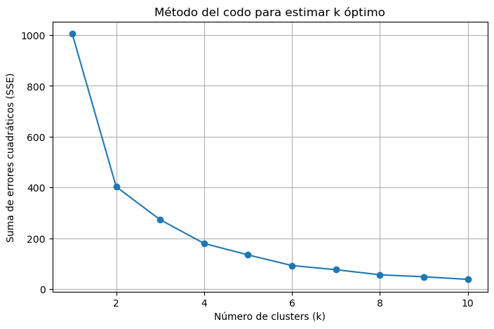

```python
codo_kmean(X)
```

**Análisis:** ¿Qué se interpreta en la gráfica? ¿Cómo podría mejorarse la elección de $k$?.

El valor de SSE decrece gradualmente sin formar un codo claro, con lo que podemos asumir que K-means tiene dificultad para separar bien estos datos. Esto ocurre porque los datos tienen forma de media luna, incompatibles con la geometría esférica que K-means espera.

**Implementación:** Cálculo y visualización de los grupos en el dataset Moons.

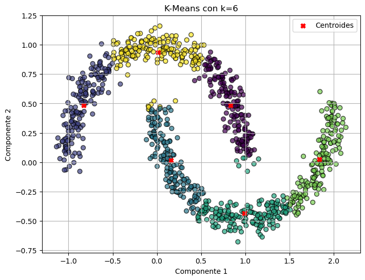

```python
visualization_kmean(X, 6)
```

**Análisis:** ¿Qué ha sucedido? Explica los motivos por los que crees que se ha producido ese resultado.

En este tipo de datos, K-means fragmenta incorrectamente los datos porque busca minimizar distancia a centroides. Para estas estructuras, algoritmos basados en densidad (DBSCAN) o conectividad (clustering jerárquico) serían más apropiados, ya que pueden capturar formas arbitrarias.

```python
X, y = X_circles, y_circles
```

**Implementación:** Cálculo y visualización de la regla del codo en el dataset Circles.

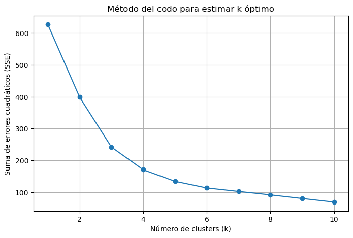

```python
codo_kmean(X)
```

**Análisis:** ¿Qué se interpreta en la gráfica? ¿Cómo podría mejorarse la elección de $k$?.

Es una gráfica bastante similar a la anterior, no hay un punto tan claro donde el SSE se estabilice para pocos clusters. Viendo la dispersión de los datos es normal pensar de nuevo en que un algoritmo de clustering por densidad sería la mejor manera de agrupar estos datos.

**Implementación:** Cálculo y visualización de los grupos en el dataset Circles.

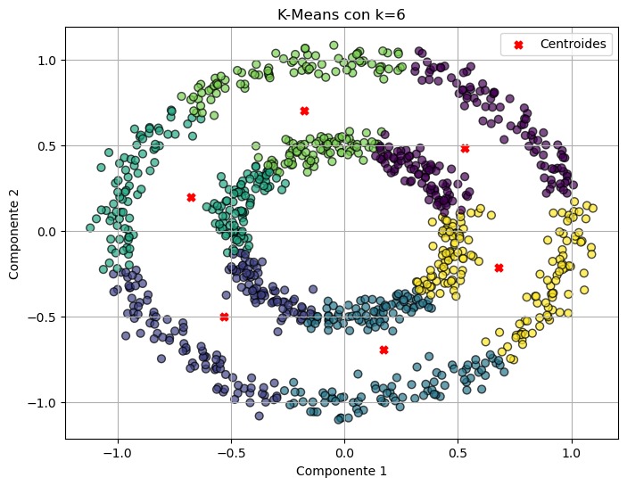

```python
visualization_kmean(X, 6)
```

**Análisis:** ¿Qué ha sucedido? Explica los motivos por los que crees que se ha producido ese resultado.

Similar al caso de Moons, K-means no identifica correctamente los círculos concéntricos de este tipo de datos. El algoritmo divide radialmente el espacio, fragmentando el anillo exterior y el interior. Esto ocurre porque K-means no puede modelar relaciones de densidad radial ni estructuras anidadas.

### 1 b. Algoritmos basados en densidad: DBScan

En este apartado se pide aplicar clustering por densidad como DBSCAN a los datasets anteriores para detectar los grupos subyacentes.

```python
def visualization_dbscan(eps_values, min_samples_values, X):
    # Visualizacion basándome en https://scikit-learn.org/stable/auto_examples/cluster/plot_dbscan.html#sphx-glr-auto-examples-cluster-plot-dbscan-py
    fig, axes = plt.subplots(len(eps_values), len(min_samples_values), figsize=(12, 10))
    fig.suptitle("DBSCAN - Banco de pruebas", fontsize=16)

    for i, eps in enumerate(eps_values):
        for j, min_samples in enumerate(min_samples_values):
            ax = axes[i, j]
            dbscan = DBSCAN(eps=eps, min_samples=min_samples)
            labels = dbscan.fit_predict(X)
            unique_labels = set(labels)
            colors = [plt.cm.viridis(k / max(len(unique_labels) - 1, 1)) for k in range(len(unique_labels))]

            for k, col in zip(unique_labels, colors):
                mask = (labels == k)

                if k == -1:
                    # Puntos de ruido marcados con 'x'
                    ax.scatter(
                        X[mask, 0],
                        X[mask, 1],
                        c='red',
                        s=40,
                        marker='x',
                        alpha=0.7
                    )
                else:
                    # Clusters normales marcados con círculos
                    ax.scatter(
                        X[mask, 0],
                        X[mask, 1],
                        c=[col],
                        s=30,
                        marker='o',
                        alpha=0.7,
                        edgecolor='k'
                    )

            n_clusters = len(set(labels)) - (1 if -1 in labels else 0)
            n_noise = list(labels).count(-1)
            ax.set_title(f"eps={eps}, min_samples={min_samples}\nclusters={n_clusters}, ruido={n_noise}")
            ax.grid(True)

    plt.tight_layout(rect=[0, 0, 1, 0.96])
    plt.show()
```

```python
X, y = X_blobs, y_blobs
```

**Implementación:** Prueba la implementación de [DBSCAN en scikit-learn](http://scikit-learn.org/stable/modules/generated/sklearn.cluster.DBSCAN.html) jugando con los parámetros *eps* y *min_samples* para encontrar los grupos (y *outliers*) del dataset Blobs.

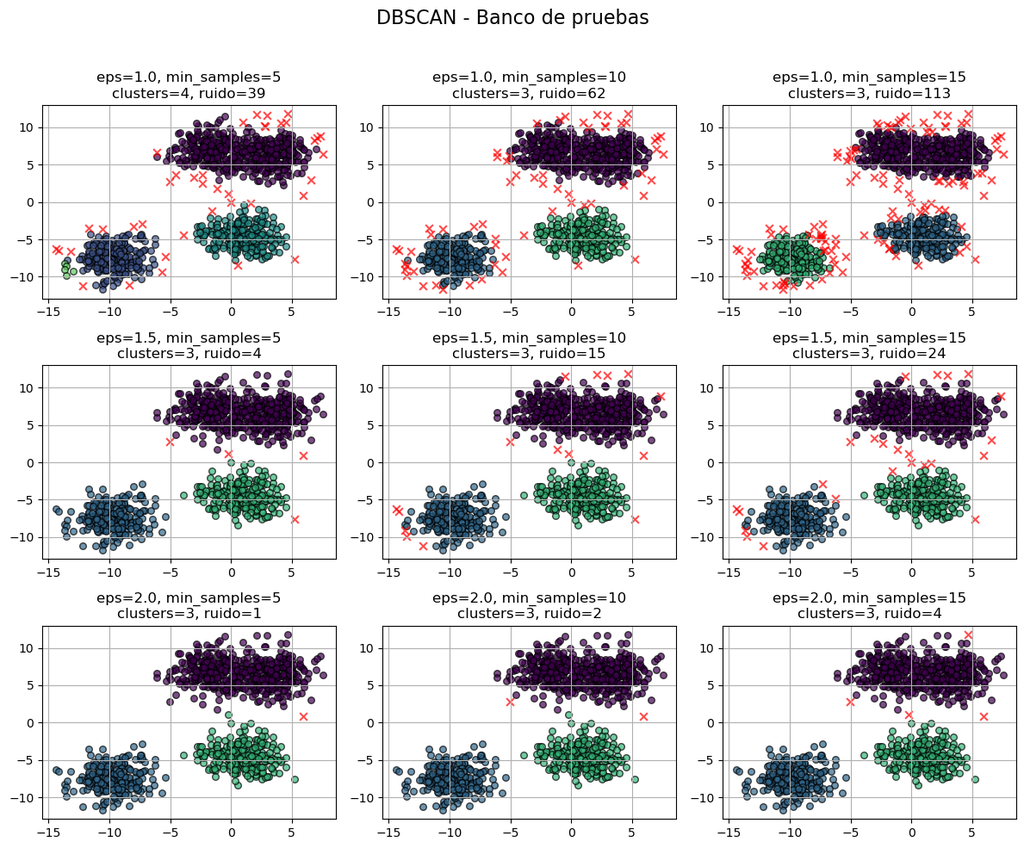

```python
eps_values = [1.0, 1.5, 2.0]
min_samples_values = [5, 10, 15]

visualization_dbscan(eps_values, min_samples_values, X)
```

**Análisis:** ¿Qué ha sucedido? Explica los motivos por los que crees que se ha producido ese resultado.

He probado con 9 configuraciones diferentes probando diferentes valores de epsilon y min_samples. El primer valor, epsilon, nos indica la distancia mínima a la que deben estar dos puntos para considerarlos de un mismo cluster. El valor de min_samples nos indica el valor mínimo de muestras para considerar un cluster.

Los puntos más alejados a la mayor densidad de cluster, que no han podido formar un cluster por el valor de min_samples se marcan como ruido.

```python
X, y = X_moons, y_moons
```

**Implementación:** Prueba la implementación de DBSCAN jugando con los parámetros *eps* y *min_samples* para encontrar los grupos (y *outliers*) del dataset Moons.

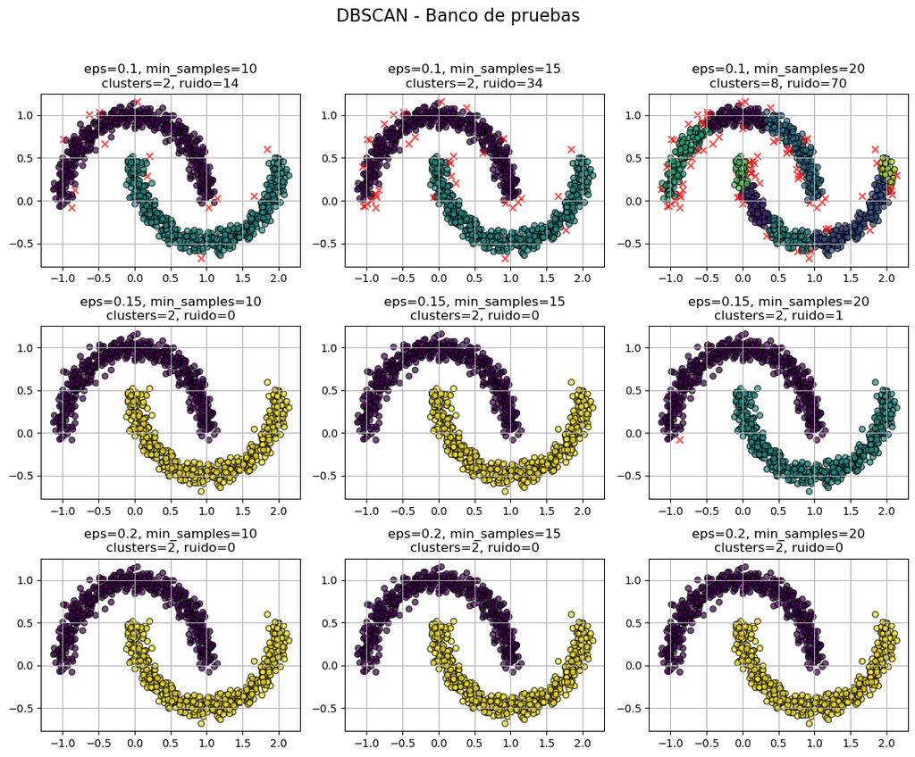

```python
eps_values = [0.1, 0.15, 0.2]
min_samples_values = [10, 15, 20]

visualization_dbscan(eps_values, min_samples_values, X)
```

**Análisis:** ¿Qué ha sucedido? Explica los motivos por los que crees que se ha producido ese resultado.

En este tipo de dataset, sí que podemos, con la percepción humana observar dos conjuntos de datos ya que están dividos con puntos cercanos. Con la regla del codo y k-means era dificil separarlo pero con clusters de densidad de puntos como el dbscan puede verse que hay configuraciones que funcionan perfectamente y otras que presentan un poco de ruido que podemos evitar con el valor de epsilon.

```python
X, y = X_circles, y_circles
```

**Implementación:** Prueba la implementación de DBSCAN jugando con los parámetros *eps* y *min_samples* para encontrar los grupos (y *outliers*) del dataset Circles.

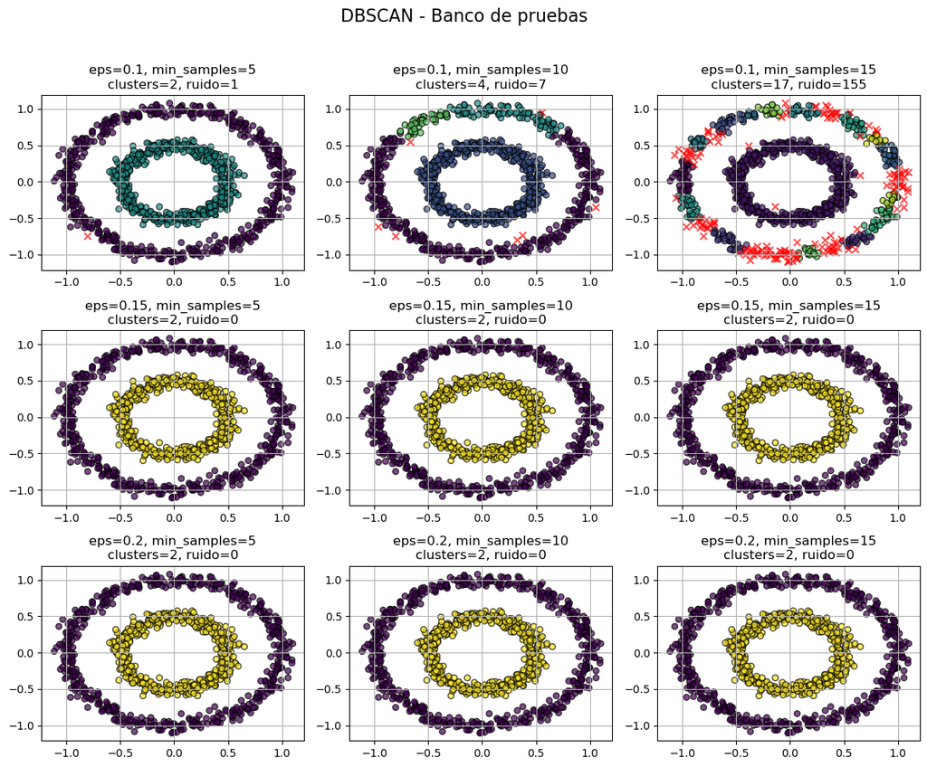

```python
eps_values = [0.1, 0.15, 0.2]
min_samples_values = [5, 10 ,15]

visualization_dbscan(eps_values, min_samples_values, X)
```

**Análisis:** ¿Qué ha sucedido? Explica los motivos por los que crees que se ha producido ese resultado.

Lo mismo que con el dataset anterior, visualmente podemos separar dos conjuntos de datos, el algoritmo de densidad dbscan, con los parámetros bien ajustado ha sabido diferenciar bien los dos clusters según la densidad de los datos reprensentados.

### 1 c. Algoritmos jerárquicos

En este apartado se pide visualizar mediante un [dendrograma](https://en.wikipedia.org/wiki/Dendrogram) la construcción progresiva de los grupos mediante un algoritmo jerárquico aglomerativo (estrategia *bottom-up*). Con ello se pretende encontrar un método gráfico para entender el comportamiento del algoritmo y encontrar los *clusters* deseados en cada dataset.

```python
def visualization_jerarquico(X, t_values):
    methods = ["single", "complete", "average", "weighted", "centroid", "median", "ward"]

    # Aumenta figsize para plots más grandes (ancho, alto)
    fig, axes = plt.subplots(len(methods), len(t_values), figsize=(20, 18))
    plt.subplots_adjust(hspace=0.3, wspace=0.2)

    for i, method in enumerate(methods):
        Z = linkage(X, method=method)
        for j, t in enumerate(t_values):
            labels = fcluster(Z, t=t, criterion="maxclust")
            ax = axes[i, j]

            ax.scatter(X[:, 0], X[:, 1], c=labels, cmap="tab10", s=20, alpha=0.8, edgecolor='k')
            ax.set_title(f"{method.title()} | k={t}", fontsize=11)
            ax.set_xticks([])
            ax.set_yticks([])

    fig.suptitle("Comparativa de métodos de enlace en clustering jerárquico", fontsize=16)
    plt.show()
```

```python
def comparar_dendrogramas(X, figsize=(20, 15)):

    methods = ["single", "complete", "average", "weighted", "centroid", "median", "ward"]

    n_methods = len(methods)
    n_cols = 2
    n_rows = (n_methods + 1) // 2

    fig, axes = plt.subplots(n_rows, n_cols, figsize=figsize)
    axes = axes.flatten() if n_methods > 1 else [axes]

    for idx, method in enumerate(methods):
        ax = axes[idx]

        # Calcular el linkage
        Z = linkage(X, method=method)

        # Crear el dendrograma
        dendrogram(
            Z,
            ax=ax,
            color_threshold=0,
            above_threshold_color='#808080',
            leaf_font_size=8,
            no_labels=True  # Cambia a False si quieres ver las etiquetas
        )

        ax.set_title(f"Método: {method.title()}", fontsize=14, fontweight='bold')
        ax.set_xlabel("Índice de muestra", fontsize=11)
        ax.set_ylabel("Distancia", fontsize=11)
        ax.grid(axis='y', alpha=0.3, linestyle='--')

    # Ocultar ejes sobrantes si el número de métodos es impar
    for idx in range(n_methods, len(axes)):
        axes[idx].axis('off')

    plt.suptitle("Dendrogramas - Comparativa de métodos de enlace",
                 fontsize=16, fontweight='bold', y=0.995)
    plt.tight_layout()
    plt.show()
```

```python
def visualizar_dendrograma_detallado(X, method='ward', max_clusters=5, figsize=(15, 8)):

    Z = linkage(X, method=method)

    plt.figure(figsize=figsize)

    # Crear dendrograma con colores
    dend = dendrogram(
        Z,
        color_threshold=None,
        leaf_font_size=10,
        no_labels=False if X.shape[0] <= 50 else True
    )

    # Añadir líneas horizontales para diferentes números de clusters
    if max_clusters:
        from scipy.cluster.hierarchy import fcluster
        colors = plt.cm.tab10(range(max_clusters))

        for k in range(2, max_clusters + 1):
            # Calcular el umbral de distancia para k clusters
            clusters = fcluster(Z, t=k, criterion='maxclust')
            threshold = Z[-(k-1), 2]

            plt.axhline(y=threshold, color=colors[k-2], linestyle='--',
                       linewidth=2, alpha=0.7,
                       label=f'k={k} clusters')

    plt.title(f"Dendrograma detallado - Método: {method.title()}",
              fontsize=16, fontweight='bold', pad=20)
    plt.xlabel("Índice de muestra (o tamaño del cluster)", fontsize=12)
    plt.ylabel("Distancia", fontsize=12)
    plt.grid(axis='y', alpha=0.3, linestyle='--')

    if max_clusters:
        plt.legend(loc='upper left', fontsize=10)

    plt.tight_layout()
    plt.show()
```

```python
X, y = X_blobs, y_blobs
```

**Implementación:** Prueba la implementación de [clustering jerárquico de scipy](https://docs.scipy.org/doc/scipy/reference/cluster.hierarchy.html) probando distintos [criterios de enlace o *linkage*](https://en.wikipedia.org/wiki/Hierarchical_clustering#Linkage_criteria) permitiendo identificar los clusters subyacentes (mostrando su resultado) y su dendrograma para el dataset Blobs.  
Puedes importar las librerías necesarias para ello.

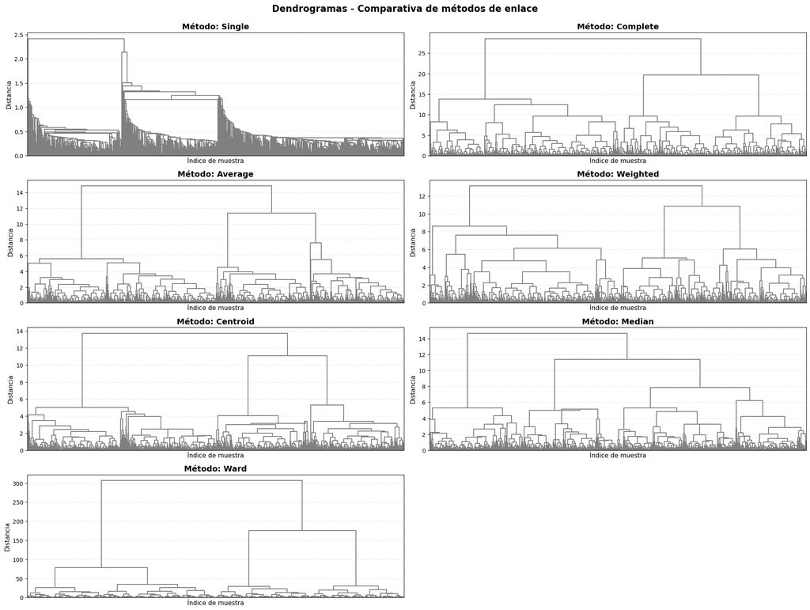

```python
comparar_dendrogramas(X)
```

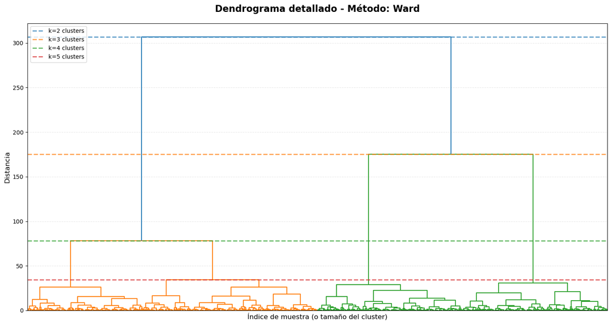

```python
visualizar_dendrograma_detallado(X, method="ward")
```

```python
# Si quieren verse los clusters de todos con diferentes métodos descomentar la siguiente línea
# visualization_jerarquico(X, range(2,5))
```

**Análisis:** Interpreta el dendrograma y comenta qué criterio de enlace se ha comportado mejor. ¿Por qué?

El dendograma representa un agrupamiento de los datos, de abajo hacia arriba se interpretan las fusiones de datos como diferentes clusters y cuanto más ascienden más les cuesta juntarse, esa distancia del eje Y y más dispares son los clusters, por lo cual tenemos que buscar un dendograma con fusiones bien marcadas, separadas y cuyas últimas fusiones tengan distancias separadas, así podemos intuir el número óptimo de clusters.

Con los datos de blob tenemos varios dendogramas que se ven bien estas fusiones y saltos pero hay uno que, a mi parecer, destaca sobre el resto, que es el del método "ward". He elegido este método ya que presenta las divisiones más estables, dejando todas las fusiones primerizas con distancias muy pequeñas y debajo del dendograma, cosas que algunos otros métodos arrastran hasta la mitad del mismo, y dejando fusiones de grupos más grande con mayor distancia.

```python
X, y = X_moons, y_moons
```

**Implementación:** Prueba la implementación de [clustering jerárquico de scipy](https://docs.scipy.org/doc/scipy/reference/cluster.hierarchy.html) probando distintos [criterios de enlace o *linkage*](https://en.wikipedia.org/wiki/Hierarchical_clustering#Linkage_criteria) permitiendo identificar los clusters subyacentes (mostrando su resultado) y su dendrograma para el dataset Moons.  
Puedes importar las librerías necesarias para ello.

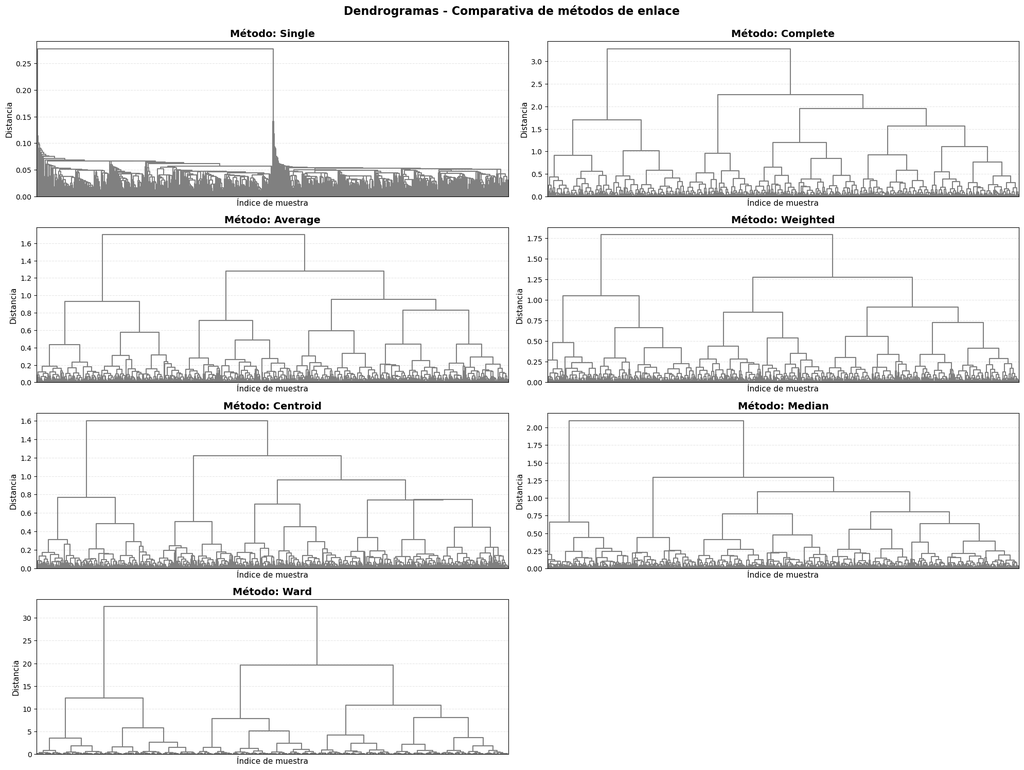

```python
comparar_dendrogramas(X)
```

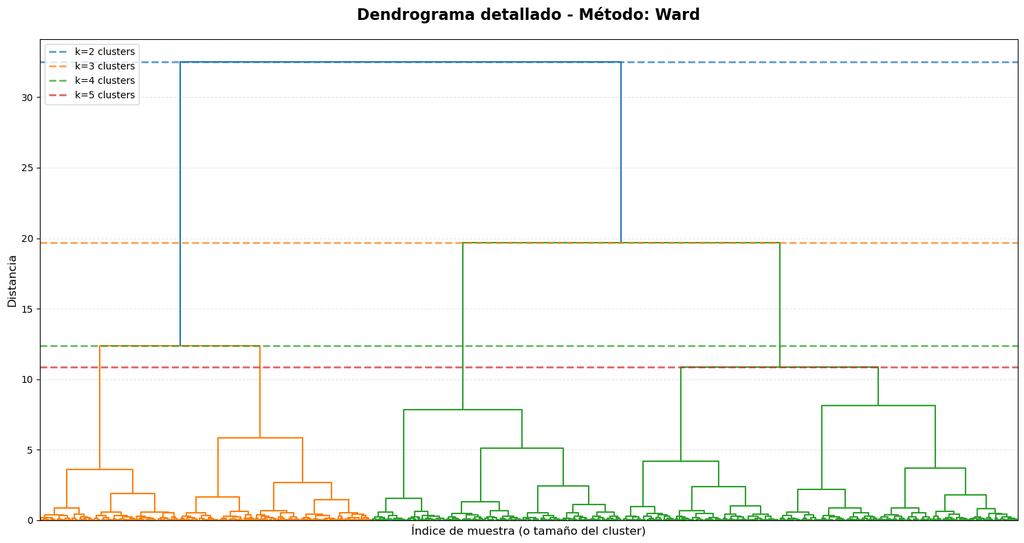

```python
visualizar_dendrograma_detallado(X, method="ward")
```

```python
# visualization_jerarquico(X, range(2,5))
```

**Análisis:** Interpreta el dendrograma y comenta qué criterio de enlace se ha comportado mejor. ¿Por qué?

Según los dendogramas de los datos de moon volvería a quedarme con el método de "ward" por lo mismo que antes. Es el método que presenta mejor la separación de los datos y hace la fusión de datos más limpia. Además, presenta también la mayor final de fusión entre los clusters.

```python
X, y = X_circles, y_circles
```

**Implementación:** Prueba la implementación de [clustering jerárquico de scipy](https://docs.scipy.org/doc/scipy/reference/cluster.hierarchy.html) probando distintos [criterios de enlace o *linkage*](https://en.wikipedia.org/wiki/Hierarchical_clustering#Linkage_criteria) permitiendo identificar los clusters subyacentes (mostrando su resultado) y su dendrograma para el dataset Circles.  
Puedes importar las librerías necesarias para ello.

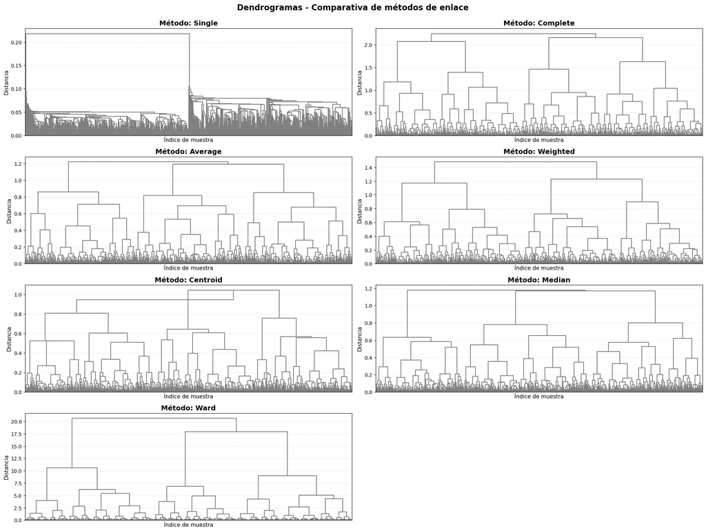

```python
comparar_dendrogramas(X)
```

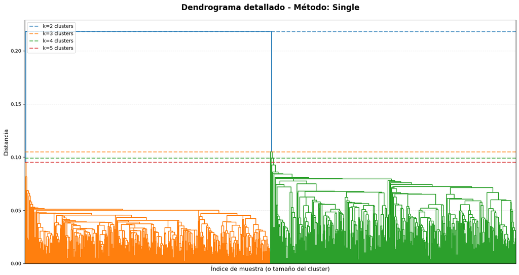

```python
visualizar_dendrograma_detallado(X, method="single")
```

```python
# visualization_jerarquico(X, range(2,5))
```

**Análisis:** Interpreta el dendrograma y comenta qué criterio de enlace se ha comportado mejor. ¿Por qué?

Sin embargo, viendo los dendogramas, aunque este presente la mayor distancia final entre grupos de datos, son muy caóticas sus fusiones iniciales. Con esto visto, por la estructura de las fusiones de los datos volvería a quedarme una tercera vez con el método de "ward". Aunque tiene fusiones de datos muytardias y con pocas distancias sus estructuras están más diferenciadas que en el resto de métodos.

## 2. *Clustering* y reducción de dimensionalidad culinaria: (6 puntos)

Probaremos distintas formas de representar las recetas: desde una codificación one-hot basada en los ingredientes, hasta embeddings semánticos generados con modelos de lenguaje (como MiniLM). Con ello veremos cómo cambia la estructura de los datos según el tipo de representación y qué tipo de similitud capturan mejor.

Finalmente aplicaremos técnicas de reducción de dimensionalidad con UMAP y varios métodos de clustering que podrás probar (KMeans, DBSCAN, HDBSCAN, Mean-shift, jerárquico...) para visualizar y analizar los grupos resultantes. Terminaremos interpretando los clusters más grandes a través de sus ingredientes y recetas representativas, comparando qué enfoque refleja mejor la *lógica culinaria* del conjunto.

```python
df = pd.read_csv('recipes.csv')
df.head(3)
```

|  | id | name | description | ingredients | ingredients_raw_str | serving_size | servings | steps | tags | search_terms |
| --- | --- | --- | --- | --- | --- | --- | --- | --- | --- | --- |
| 0 | 56594 | Sun-Dried Tomato Palmiers | from "INVITATION TO DINNER" cookbook | ['garlic cloves', 'pesto sauce', 'frozen puff ... | ["2 garlic cloves, peeled and finely min... | 1 (675 g) | 1 | ['Preheat the oven to 350 degrees F.', 'Stir t... | ['60-minutes-or-less', 'time-to-make', 'course... | {'appetizer'} |
| 1 | 311362 | Char Siu Pork Corn and Bok Choy Stir Fry | Here is another wok recipe I like stir fry's a... | ['peanut oil', 'pork fillets', 'garlic cloves'... | ["2 tablespoons peanut oil","600 g p... | 1 (364 g) | 4 | ['Heat 1 tabelspoon of oil in a wok and cook p... | ['60-minutes-or-less', 'time-to-make', 'course... | {'pork', 'dinner'} |
| 2 | 248335 | Black Cat Fudge | These adorable fudge peices will be a huge hit... | ['semisweet chocolate', 'butter', 'light corn ... | ["8 ounces semisweet chocolate, coarsely ... | 1 (42 g) | 24 | ['Line 11x7 inches pan with foil, extending fo... | ['time-to-make', 'course', 'preparation', 'occ... | {'dessert'} |

**Implementación:** Crea una nueva columna en el *DataFrame* que contenga, en una sola cadena de texto, **toda la información disponible de cada receta**. Concatena, en ese orden:

- Título (`name`)
- Descripción (`description`)
- Lista de ingredientes (`ingredients`)
- Pasos de preparación (`steps`)
- Etiquetas (`tags`) y, si existe, términos de búsqueda (`search_terms`)

Esta columna representará una descripción textual completa de la receta y se usará en el siguiente paso para generar sus **embeddings semánticos**.

Ten en cuenta:

- Convierte listas o conjuntos a texto legible (por ejemplo, separando por comas).
- Gestiona valores nulos para evitar errores de concatenación.
- Verifica que el texto resultante mantiene la información relevante y es coherente.

```python
def process_field(value):
    if pd.isna(value) or value is None:
        return ""

    # Si es una lista o conjunto, convertir a texto separado por comas
    if isinstance(value, (list, set, tuple)):
        # Filtrar valores nulos dentro de la lista
        clean_list = [str(item) for item in value if pd.notna(item)]
        return ", ".join(clean_list)

    # Si es otro tipo, convertir a string
    return str(value)

def create_full_text_column(df: pd.DataFrame):
    # Verificar que las columnas existen
    required_cols = ['name', 'description', 'ingredients', 'steps', 'tags']
    missing_cols = [col for col in required_cols if col not in df.columns]
    if missing_cols:
        print(f"Advertencia: Columnas faltantes: {missing_cols}")

    # Crear la columna full_text
    df['full_text'] = (
        "Título: " + df['name'].apply(process_field) + ". " +
        "Descripción: " + df['description'].apply(process_field) + ". " +
        "Ingredientes: " + df['ingredients'].apply(process_field) + ". " +
        "Pasos: " + df['steps'].apply(process_field) + ". " +
        "Etiquetas: " + df['tags'].apply(process_field) +
        # Añadir search_terms solo si la columna existe
        (". Términos de búsqueda: " + df['search_terms'].apply(process_field)
         if 'search_terms' in df.columns else "")
    )

    # Limpiar espacios múltiples y puntos duplicados por si los hubiera.
    df['full_text'] = df['full_text'].str.replace(r'\s+', ' ', regex=True)
    df['full_text'] = df['full_text'].str.replace(r'\.+', '.', regex=True)
    df['full_text'] = df['full_text'].str.strip()

    return df

df = create_full_text_column(df)

print(df['full_text'].iloc[0])
```

```
Título: Sun-Dried Tomato Palmiers. Descripción: from "INVITATION TO DINNER" cookbook. Ingredientes: ['garlic cloves', 'pesto sauce', 'frozen puff pastry', 'fontina', 'parmigiano-reggiano cheese', 'sun-dried tomato', 'fresh ground black pepper']. Pasos: ['Preheat the oven to 350 degrees F.', 'Stir th…
```

**Implementación:** Genera los **embeddings semánticos** de las recetas utilizando el modelo `all-MiniLM-L6-v2` de la librería `sentence-transformers`. Este modelo es una versión ligera de BERT que transforma frases completas en vectores numéricos que capturan su significado.

Usa como entrada la columna con toda la información de la receta (título, descripción, ingredientes, pasos y etiquetas) para obtener una representación semántica de cada una.

Incrementa el parámetro `batch_size` en `encode()` para aprovechar mejor los recursos y activa `show_progress_bar=True` para visualizar el progreso durante la generación de embeddings.

```python
# Cargar el modelo
print("Cargando modelo all-MiniLM-L6-v2...")
model = SentenceTransformer('all-MiniLM-L6-v2', device="cuda")
print(f"✓ Modelo cargado")

# Filtrar recetas con texto válido
df_valid = df[df['full_text'].notna() & (df['full_text'].str.len() > 0)].copy()

# Para reducir el tiempo, podemos reducir el dataset
len_new_df = len(df_valid)/1

# Generar embeddings
print("\nGenerando embeddings semánticos...")
df_valid = df_valid.sample(n=int(len_new_df), random_state=seed).copy()

embeddings = model.encode(
    df_valid['full_text'].tolist(),
    batch_size=256,
    show_progress_bar=True,     # Solo para ver el proceso y reducir/aumentar número de muestras si acaso
    normalize_embeddings=True,  # Normalizar los embeddings
    convert_to_numpy=True       # numpy en vez de un tensor de PyTorch
)
```

```
Cargando modelo all-MiniLM-L6-v2...
✓ Modelo cargado

Generando embeddings semánticos...
```

**Implementación:** Reduce los **embeddings** obtenidos a un espacio de **2 dimensiones** utilizando `UMAP` (*Uniform Manifold Approximation and Projection*), una técnica de reducción de dimensionalidad que conserva la estructura local de los datos en espacios de alta dimensión.

UMAP busca representar los datos en un espacio más pequeño manteniendo la relación entre puntos similares, lo que lo hace ideal para visualizar embeddings en 2D y detectar grupos o patrones de manera intuitiva. En comparación con *t-SNE*, UMAP es más rápido, escalable, permite la proyección de nuevos puntos y preserva mejor la estructura global de los datos. Puedes consultar una comparación visual detallada en [esta página](https://pair-code.github.io/understanding-umap/).

Aplica UMAP sobre la matriz de embeddings y guarda el resultado en una nueva variable que contenga las coordenadas 2D de cada receta para su posterior visualización o análisis.

```python
# Crear el reductor UMAP
reducer = umap.UMAP(
    n_components=2,             # Reducir a 2 dimensiones
    n_neighbors=15,             # Número de vecinos a considerar
    min_dist=0.1,               # Distancia mínima entre puntos en el espacio reducido
    metric='cosine',            # Métrica de distancia (cosine para embeddings de texto)
    random_state=seed,          # Para reproducibilidad
    n_jobs=1                    # 1 job obligado por el random_state con la semilla
)

# Aplicar UMAP
embeddings_2d = reducer.fit_transform(embeddings)

print(f"✓ Reducción completada")
print(f"  - Dimensión reducida: {embeddings_2d.shape[1]}D")
print(f"  - Shape final: {embeddings_2d.shape}")
print(f"  - Rango X: [{embeddings_2d[:, 0].min():.2f}, {embeddings_2d[:, 0].max():.2f}]")
print(f"  - Rango Y: [{embeddings_2d[:, 1].min():.2f}, {embeddings_2d[:, 1].max():.2f}]")

df_valid['umap_x'] = embeddings_2d[:, 0]
df_valid['umap_y'] = embeddings_2d[:, 1]
```

```
✓ Reducción completada
  - Dimensión reducida: 2D
  - Shape final: (50000, 2)
  - Rango X: [-7.21, 10.86]
  - Rango Y: [-2.21, 16.80]
```

**Implementación:** Visualiza el resultado de la reducción a 2D con `UMAP` mediante un **scatter plot**. Representa cada receta como un punto en el plano y observa si se forman grupos o regiones con mayor densidad.

Para mejorar la legibilidad del gráfico:

- Ajusta el parámetro `alpha` para controlar la **transparencia** de los puntos: valores más bajos (por ejemplo, 0.3) permiten visualizar mejor las zonas donde los puntos se solapan, haciendo más visibles las regiones densas.
- Reduce el parámetro `s` (tamaño de los puntos) para evitar que se superpongan en exceso y poder distinguir mejor la estructura general del conjunto.

```python
def visualizar_umap(x_values, y_values, title, color='cyan'):
    plt.figure(figsize=(12, 8))

    plt.scatter(
        x_values,
        y_values,
        s=20,                  # Tamaño de puntos
        alpha=0.2,             # Transparencia
        c=color,               # Color de los puntos
        edgecolors='black'
    )

    plt.title(title, fontsize=16, fontweight='bold')
    plt.grid(True, alpha=0.2, linestyle='--')
    plt.tight_layout()

    plt.show()
```

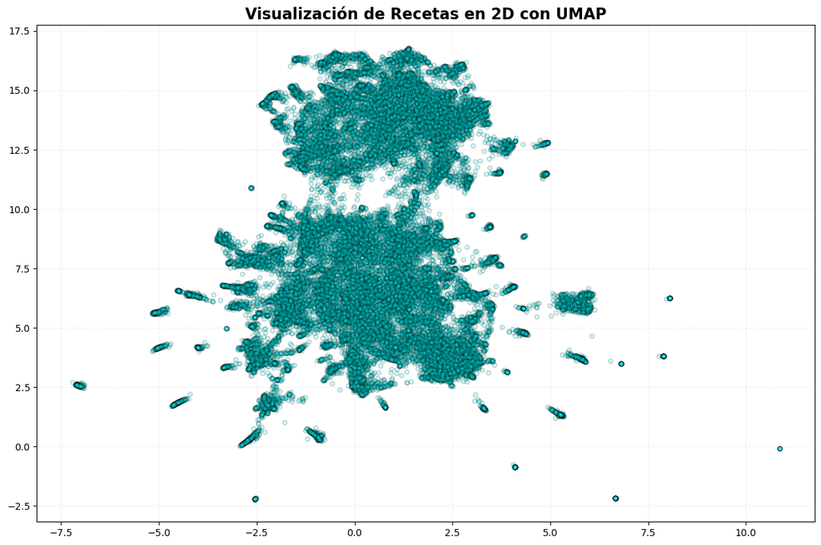

```python
visualizar_umap(df_valid['umap_x'], df_valid['umap_y'], 'Visualización de Recetas en 2D con UMAP', 'cyan')
```

**Análisis:** **sobre qué datos realizar el clustering**: ¿sobre los datos reducidos en 2D o sobre los embeddings originales en alta dimensionalidad?

Justifica tu elección explicando las posibles consecuencias de aplicar el algoritmo de clustering sobre una representación reducida en comparación con la original.

Siempre que sea posible es conveniente realizar el clustering de los datos sobre los embeddings originales, con todas sus dimensiones para intentar no perder ninguna información en el proceso.

UMAP preserva la estructura local, pero distorsiona distancias globales, lo que puede afectar a varios algoritmos basados en distancias.

Si fueran datos que tuviera pocas dimensiones, que con pocas de ellas se pueda explicar bien el dato o que, en la representación del UMAP vieramos patrones bien diferenciados podriamos coger los datos reducidos, aunque esto solo nos mejoraría la velocidad de procesado.

**Implementación:** Visualiza las recetas en su **espacio original de alta dimensionalidad** utilizando un **dendrograma**. Esto te permitirá analizar la estructura de los datos y comparar si las agrupaciones observadas coinciden con las que aparecían en la proyección 2D de `UMAP`.

Comenta qué puedes inferir al observar el dendrograma: si existen grupos bien definidos o si las fusiones son graduales, y cómo se relaciona esa estructura jerárquica con las regiones que aparecían en la visualización reducida.

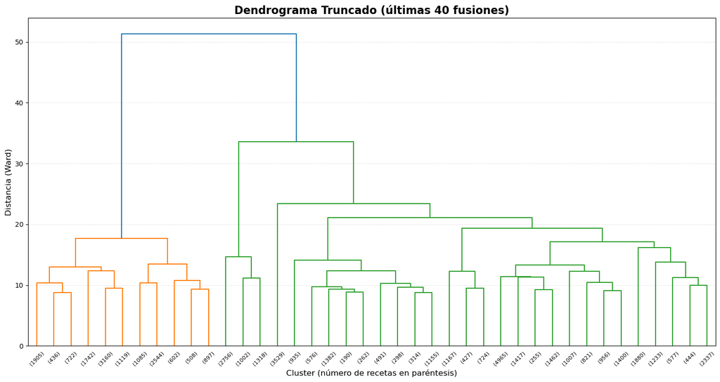

```python
linkage_matrix = linkage(embeddings, method='ward')

# Dendrograma con truncamiento para visualizar mejor la estructura de alto nivel
plt.figure(figsize=(15, 8))

dendrogram(
    linkage_matrix,
    truncate_mode='lastp',    # Mostrar solo los últimos p clusters fusionados
    p=40,                      # Número de clusters a mostrar, reducimos ya que hay muchos datos
    show_leaf_counts=True,     # Mostrar cuántas recetas hay en cada rama
    color_threshold=None
)

plt.title('Dendrograma Truncado (últimas 40 fusiones)',
          fontsize=16, fontweight='bold')
plt.xlabel('Cluster (número de recetas en paréntesis)', fontsize=12)
plt.ylabel('Distancia (Ward)', fontsize=12)
plt.grid(axis='y', alpha=0.3, linestyle='--')
plt.tight_layout()

plt.show()
```

Del dendograma podemos ver que, como en la representación, hay dos grupos bien diferenciados, marcados de naranja y verde, estos correponderían a las zonas de datos de visualización con mayor densidad.

Después podemos intuir que, los pequeños grupos de islas de la visualización correponden a fusiones menores de dendograma, grupos pequeños que se fusionan en un grupo mayor.

He tenido que truncar el dendograma por la cantidad de datos pero podemos ver las primeras fusiones con distancias parecidas y las últimas que van cogiendo mayor distancia de fusión lo que podría indicarnos diferentes clusters de nuestros datos.

**Análisis:** Dado lo observado en la reducción de dimensionalidad con `UMAP` y en el dendrograma obtenido, decide **qué algoritmo de clustering** utilizarías para identificar los grupos de recetas. Explica con qué argumentos lo elegirías y justifica tu respuesta en función de la estructura observada en los datos (densidad, tamaño y forma de los grupos).

He decidido utilizar HDBSCAN porque los datos en 2D de las recetas presentan una estructura algo irregular, con dos zonas muy densas en el centro y alrededor varias agrupaciones de datos. Ante esta distribución, HDBSCAN resulta adecuado al poder detectar clusters de densidad variable sin necesidad de fijar un número de grupos y gestionando de forma natural el ruido, a diferencia de métodos como K-Means o DBSCAN que requieren una estructura más rígida.

**Implementación:** Implementa el algoritmo elegido y analiza sus posibles parámetros para obtener el resultado deseado.

```python
# # Hacemos un pequeño banco de pruebas para ver los mejores hiper-parámetros del HDBSCAN

# # Parámetros a probar
# min_cluster_sizes = [10, 15, 20]
# min_samples_values = [6, 7]
# methods = ['eom', 'leaf']

# results = []

# for mcs in min_cluster_sizes:
#     for ms in min_samples_values:
#         for method in methods:

#             clusterer = hdbscan.HDBSCAN(
#                 min_cluster_size=mcs,
#                 min_samples=ms,
#                 cluster_selection_method=method,
#                 core_dist_n_jobs=-1
#             )
#             labels = clusterer.fit_predict(embeddings)

#             n_clusters = len(set(labels)) - (1 if -1 in labels else 0)
#             n_outliers = sum(labels == -1)

#             # Una opción para ver cual es el mejor es calcular el silhouette_score
#             # https://scikit-learn.org/stable/modules/generated/sklearn.metrics.silhouette_score.html
#             if n_clusters > 1 and n_outliers < len(labels):
#                 # Filtrar outliers para métricas
#                 mask = labels >= 0
#                 if sum(mask) > 0:
#                     silhouette = silhouette_score(embeddings[mask], labels[mask])
#                 else:
#                     silhouette = -1
#             else:
#                 silhouette = -1

#             results.append({
#                 'min_cluster_size': mcs,
#                 'min_samples': ms,
#                 'method': method,
#                 'n_clusters': n_clusters,
#                 'n_outliers': n_outliers,
#                 'pct_clustered': (len(labels) - n_outliers) / len(labels) * 100,
#                 'silhouette': silhouette
#             })
#             print(results)

# # Ordenar por silhouette score
# results_sorted = sorted(results, key=lambda x: x['silhouette'], reverse=True)

# print("TOP 10 MEJORES CONFIGURACIONES (por Silhouette Score)")
# print("-"*60)
# print(f"{'Rank':<5} {'mcs':<5} {'ms':<5} {'method':<8} {'#C':<5} {'Out%':<8} {'Silhouette':<10}")
# print("-"*60)

# for i, r in enumerate(results_sorted[:10], 1):
#     print(f"{i:<5} {r['min_cluster_size']:<5} {r['min_samples']:<5} {r['method']:<8}"
#           f"{r['n_clusters']:<5} {100-r['pct_clustered']:>6.1f}% {r['silhouette']:>9.4f}")

# # Una vez tenemos la mejor configuración hacemos la predicción con esa
# best = results_sorted[0]

clusterer_fainal = hdbscan.HDBSCAN(
    min_cluster_size=15,
    min_samples=7,
    cluster_selection_method="eom",
    core_dist_n_jobs=-1,
    prediction_data=True
)

labels_final = clusterer_final.fit_predict(embeddings)
```

**Implementación:** Representa en un **scatter plot** la proyección 2D (UMAP) coloreando cada punto según su `cluster`. Usa una paleta cualitativa rica en colores (como `tab20`). Si hay más clusters que colores disponibles, reutiliza colores aplicando el índice del cluster *módulo* el número de colores de la paleta.

```python
def visualizar_clusters_umap(embeddings_2d, labels, titulo="Clustering con UMAP",
                              figsize=(14, 10), s=20, alpha=0.6):

    # Preparar colores
    unique_labels = sorted(set(labels))
    n_clusters = len([l for l in unique_labels if l != -1])
    n_outliers = sum(labels == -1)

    cmap = plt.colormaps.get_cmap('tab20')
    n_colors = 20

    # Asignar colores a cada cluster
    colors = []
    for label in labels:
        if label == -1:
            colors.append('lightgray')  # Outliers en gris
        else:
            colors.append(cmap(label % n_colors))

    # Crear figura
    fig, ax = plt.subplots(figsize=figsize)

    # Plotear outliers primero (fondo)
    outlier_mask = labels == -1
    if sum(outlier_mask) > 0:
        ax.scatter(
            embeddings_2d[outlier_mask, 0],
            embeddings_2d[outlier_mask, 1],
            c='lightgray',
            s=s,
            alpha=alpha * 0.5,
            label='Outliers',
            edgecolors='none'
        )

    # Plotear cada cluster
    for cluster_id in sorted([l for l in unique_labels if l != -1]):
        mask = labels == cluster_id
        ax.scatter(
            embeddings_2d[mask, 0],
            embeddings_2d[mask, 1],
            c=[cmap(cluster_id % n_colors)],
            s=s,
            alpha=alpha,
            label=f'Cluster {cluster_id}',
            edgecolors='white',
            linewidths=0.3
        )

    ax.set_xlabel('UMAP 1', fontsize=12)
    ax.set_ylabel('UMAP 2', fontsize=12)
    ax.set_title(titulo, fontsize=14, fontweight='bold', pad=15)

    # Leyenda
    ax.legend(bbox_to_anchor=(1.05, 1), loc='upper left',
                frameon=True, fontsize=9, ncol=1)

    ax.grid(alpha=0.3, linestyle='--')
    ax.set_axisbelow(True)

    plt.tight_layout()
    plt.show()

    return embeddings_2d
```

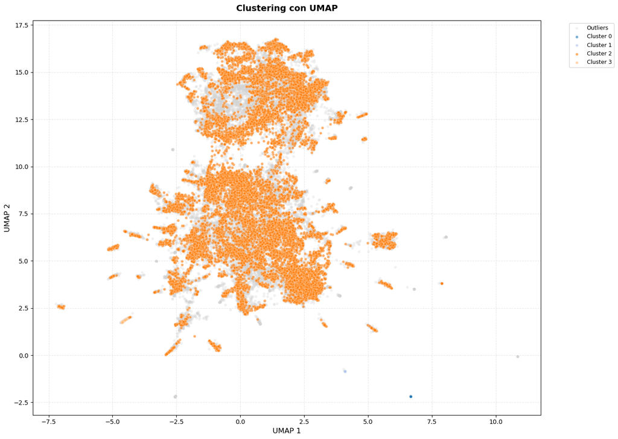

```
array([[ 2.2465239 , 11.39119   ],
       [ 1.2020888 ,  6.367242  ],
       [-2.2892263 , 14.4296665 ],
       ...,
       [ 0.9642923 , 14.117098  ],
       [ 2.362025  ,  3.3408086 ],
       [ 0.02546415,  8.744576  ]], dtype=float32)
```

```python
embedding_2d_array = df_valid[['umap_x', 'umap_y']].values
visualizar_clusters_umap(embedding_2d_array, labels_final)
```

**Implementación:** Para interpretar el clustering y validar su coherencia, selecciona los **10 grupos** con mayor tamaño y muestra, para cada uno, las **5 recetas más cercanas al centroide** (si el método lo define).

```python
def analizar_top_clusters(df, embeddings, labels):

    # Filtrar outliers
    mask = labels != -1
    labels_filtered = labels[mask]
    embeddings_filtered = embeddings[mask]
    df_filtered = df[mask].reset_index(drop=True)

    # Contar tamaño de cada cluster
    unique_labels, counts = np.unique(labels_filtered, return_counts=True)
    cluster_sizes = sorted(zip(unique_labels, counts), key=lambda x: x[1], reverse=True)

    # Analizar top 10 clusters
    for rank, (cluster_id, size) in enumerate(cluster_sizes[:10], 1):
        if size > 5:
            print(f"CLUSTER {cluster_id} - Rank #{rank} - Tamaño: {size} recetas")

            # Obtener índices de recetas en este cluster
            cluster_mask = labels_filtered == cluster_id
            cluster_embeddings = embeddings_filtered[cluster_mask]
            cluster_df = df_filtered[cluster_mask].reset_index(drop=True)

            # Calcular centroide del cluster
            centroid = cluster_embeddings.mean(axis=0).reshape(1, -1)

            # Calcular distancias de cada receta al centroide
            # Usamos distancia coseno (1 - similitud coseno)
            distances = cosine_distances(cluster_embeddings, centroid).flatten()

            # Obtener índices de las recetas más cercanas
            closest_indices = np.argsort(distances)[:5]

            print(f"\n  Top {5} recetas más cercanas al centroide:\n")

            for i, idx in enumerate(closest_indices, 1):
                recipe = cluster_df.iloc[idx]
                distance = distances[idx]
                similarity = 1 - distance  # Convertir a similitud

                print(f" RECETA #{i} - Similitud con centroide: {similarity:.4f}")

                # Mostrar varias columnas de la receta
                for col in ["name",	"ingredients", "tags", "search_terms"]:
                    value = recipe[col]

                    # Mostrar según tipo de dato
                    if pd.isna(value):
                        continue  # Saltar valores nulos
                    elif isinstance(value, str):
                        # Limitar texto largo
                        if len(str(value)) > 200:
                            print(f"  - {col}: {str(value)[:200]}...")
                        else:
                            print(f"  - {col}: {value}")
                    else:
                        print(f"  - {col}: {value}")

                print()  # Línea en blanco entre recetas para mejor separación
```

```python
analizar_top_clusters(df_valid, embeddings, labels_final)
```

```
CLUSTER 2 - Rank #1 - Tamaño: 17561 recetas

  Top 5 recetas más cercanas al centroide:

 RECETA #1 - Similitud con centroide: 0.9346
  - name: Baked Cheesy Potatoes
  - ingredients: ['o%27brien potatoes', 'sweet onion', 'cream of celery soup', 'cream of chicken soup', 'sour cream', 'shredded cheddar cheese']
  - tags: ['weeknight', 'time-to-make', 'course', 'preparation', 'occasion', 'side-dishes', 'fall', 'winter', 'seasonal', 'comfort-food', 'taste-mood', '4-hours-or-less']
  - search_terms: {'side', 'baked'}

 RECETA #2 - Similitud con centroide: 0.9342
  - name: Oatmeal Burgers
  - ingredients: ['quick oats', 'ground walnuts', 'eggs', 'onion', 'evaporated milk', 'chicken seasoning', 'soy sauce', 'cheddar cheese', 'mushroom soup', 'sour cream', 'onion powder', 'garlic powder', 'water', 'soy s...
  - tags: ['60-minutes-or-less', 'time-to-make', 'course', 'main-ingredient', 'cuisine', 'preparation', 'occasion', 'north-american', 'main-dish', 'american', 'vegetarian', 'grains', 'dietary', 'comfort-food', ...
  - search_terms: {'dinner', 'vegetarian'}

 RECETA #3 - Similitud con centroide: 0.9278
  - name: Hot Chicken Salad
  - ingredients: ['chicken meat', 'celery', 'salted almond', 'green bell pepper', 'onions', 'chopped pimiento', 'salt', 'lemon juice', 'mayonnaise', 'swiss cheese', 'potato chips']
  - tags: ['60-minutes-or-less', 'time-to-make', 'course', 'main-ingredient', 'preparation', 'occasion', 'main-dish', 'poultry', 'potluck', 'chicken', 'meat', 'to-go']
  - search_terms: {'chicken', 'dinner', 'salad'}

 RECETA #4 - Similitud con centroide: 0.9257
  - name: Hot Chicken Salad Casserole
  - ingredients: ['cooked chicken', 'cooked long-grain rice', 'slivered almonds', 'mayonnaise', 'condensed cream of chicken soup', 'chopped pimiento', 'hard-cooked eggs', 'celery', 'salt', 'green peppers', 'onions', '...
  - tags: ['time-to-make', 'course', 'main-ingredient', 'preparation', 'casseroles', 'main-dish', 'poultry', 'oven', 'chicken', 'meat', 'chicken-breasts', 'equipment', '4-hours-or-less']
  - search_terms: {'casserole', 'chicken', 'dinner', 'salad'}

 RECETA #5 - Similitud con centroide: 0.9252
  - name: Shortcut Skillet Frittata
  - ingredients: ['vegetable oil', 'frozen shredded hash browns', 'green pepper', 'bacon', 'eggs', 'milk', 'sharp cheddar cheese']
  - tags: ['30-minutes-or-less', 'time-to-make', 'course', 'main-ingredient', 'preparation', 'occasion', 'omelets-and-frittatas', 'breakfast', 'eggs-dairy', 'easy', 'dietary', 'low-carb', 'low-in-something', 'b...
  - search_terms: {'breakfast', 'low-carb'}

CLUSTER 3 - Rank #2 - Tamaño: 52 recetas

  Top 5 recetas más cercanas al centroide:

 RECETA #1 - Similitud con centroide: 0.9511
  - name: Lamb Curry
```

[output cut: 80 more lines]

```
  - ingredients: ['brussels sprouts', 'green onions', 'soda crackers', 'salt', 'pepper', 'cream of celery soup', 'milk']
  - tags: ['60-minutes-or-less', 'time-to-make', 'course', 'main-ingredient', 'preparation', 'side-dishes', 'vegetables', 'dietary']
  - search_terms: {'side', 'baked'}

 RECETA #4 - Similitud con centroide: 0.9399
  - name: Sauteed Brussels Sprouts
  - ingredients: ['brussels sprout', 'salt', 'margarine', 'red seedless grapes', 'slivered almonds', 'salt', 'pepper']
  - tags: ['30-minutes-or-less', 'time-to-make', 'course', 'main-ingredient', 'cuisine', 'preparation', 'occasion', 'north-american', 'low-protein', 'side-dishes', 'vegetables', 'canadian', 'dinner-party', 'hol...
  - search_terms: {'side', 'dinner', 'low-calorie', 'low-carb'}

 RECETA #5 - Similitud con centroide: 0.9336
  - name: 5 Minute Brussels Sprouts
  - ingredients: ['brussels sprout', 'extra virgin olive oil', 'lemon juice', 'garlic cloves', 'salt and black pepper']
  - tags: ['15-minutes-or-less', 'time-to-make', 'main-ingredient', 'preparation', 'for-1-or-2', '5-ingredients-or-less', 'vegetables', 'easy', 'vegetarian', 'dietary', 'number-of-servings']
  - search_terms: {'vegetarian'}
```

**Análisis:** Observa los resultados del clustering e interpreta si los grupos obtenidos **tienen sentido** desde un punto de vista culinario. Observa si las recetas dentro de un mismo cluster comparten ingredientes, estilo de preparación o tipo de plato (por ejemplo, salsas, postres, carnes, ensaladas...). Explica brevemente por qué crees que los clusters son o no coherentes.

El primer cluster que aparece es el más extenso de todos, es un cluster general por lo que no es necesario encontrar una relación clara entre las 5 recetas más cercanas al centroide. En este caso solo vemos una relación con 2 que son las ensaladas calientes de pollo.

En los otros clusters, más pequeños y especializados sí encontramos mejores similitudes.

En el segundo cluster más poblado encontramos recetas que tienen cordero como ingrediente principal y son especiales para la cena.

El tercer cluster más poblado tenemos recetas de mejillones, bajas en carbohidratos la mayoría de ellas.

Como cuarto mayor cluster tenemos recetas de coles de bruselas, especiales como acompañamiento.

Una vez nos alejamos del cluster general, que tiene más recetas, encontramos cluster más especializados que sí tienen datos mucho más en común con el resto.

**Implementación:** Vamos a crear una nueva representación de las recetas utilizando únicamente sus **ingredientes**. Para ello, genera una matriz *one-hot* donde cada fila representa una receta y cada columna un ingrediente distinto. En esta matriz, el valor será `1` si la receta contiene ese ingrediente y `0` en caso contrario.

Puedes utilizar la clase `MultiLabelBinarizer` de `sklearn.preprocessing` para transformar automáticamente las listas de ingredientes en vectores binarios.

- Usa la columna de ingredientes ya procesada (listas limpias y sin valores nulos).
- Guarda el resultado en una nueva variable o DataFrame y asegúrate de que el número de columnas coincide con el número total de ingredientes únicos.
- Esta representación servirá como nueva base para aplicar técnicas de reducción de dimensionalidad y clustering.

```python
# Convertir string a listas
def parse_ingredients(ing):
    if pd.isna(ing):
        return []

    # Si ya es lista, devolverla
    if isinstance(ing, list):
        return [str(i).strip().lower() for i in ing if i]

    # Si es string que parece lista (ej: "['a', 'b']")
    if isinstance(ing, str):
        try:
            # Intentar evaluar como lista
            parsed = ast.literal_eval(ing)
            if isinstance(parsed, list):
                return [str(i).strip().lower() for i in parsed if i]
        except:
            pass

        # Si tiene comas, separar por comas
        if ',' in ing:
            return [i.strip().lower() for i in ing.split(',') if i.strip()]

        # Si es un solo ingrediente
        return [ing.strip().lower()] if ing.strip() else []

    return []

# Parsear ingredientes
df_valid['ingredients_list'] = df_valid['ingredients'].apply(parse_ingredients)

# Filtrar recetas sin ingredientes
df_with_ingredients = df_valid[df_valid['ingredients_list'].map(len) > 0].copy()

# Crear matriz one-hot
mlb = MultiLabelBinarizer()

# Transformar listas de ingredientes a matriz one-hot
ingredients_onehot = mlb.fit_transform(df_with_ingredients['ingredients_list'])

ingredient_names = mlb.classes_

# Crear un DataFrame de la matriz
df_ingredients_onehot = pd.DataFrame(
    ingredients_onehot,
    columns=ingredient_names,
    index=df_with_ingredients.index
)
```

Primero, vamos a observar los ingredientes menos comunes, muchos de estos son variantes poco descriptivas de otros más comunes.

```python
# Frecuencia de cada ingrediente
freq = ingredients_onehot.sum(axis=0)

# Selección de ingredientes con < 5 apariciones
mask = freq < 5
rare_ingredients = np.array(ingredient_names)[mask]
rare_counts = freq[mask]

# Listado
rare_df = pd.DataFrame({
    "ingredient": rare_ingredients,
    "count": rare_counts
}).sort_values("count")

print(rare_df)
```

```
                                ingredient  count
0     %281 1%2f4 sticks%29 unsalted butter      1
2360           green chile sauce with pork      1
2361                     green chili paste      1
2362             green chili pepper flakes      1
4428             reduced-sodium beef stock      1
...                                    ...    ...
2912                   lean sirloin steaks      4
879                      caramelized onion      4
3861                                 pepsi      4
4654                                scotch      4
2924                           lemon basil      4

[5849 rows x 2 columns]
```

Por ello vamos a intentar normalizarlo para rebajar el número de ingredientes diferentes, haremos 3 aproximaciones.

- 1. Quitar palabras comunes como "fresh", "choped", "small".
- 2. Los ingredientes raros que contienen ingredientes comunes se absorben hacia el ingrediente común. (green chili paste => green chili).
- 3. Normalizar la aparición de singular o plural.

```python
def normalize_ingredients_normalized(df, ingredients_col='ingredients_list',
                                      freq_threshold_common=40,
                                      freq_threshold_rare=10):

    all_ingredients = []
    for ing_list in df[ingredients_col]:
        if isinstance(ing_list, list):
            all_ingredients.extend(ing_list)

    ingredient_freq = Counter(all_ingredients)

    print(f"   Total ingredientes únicos: {len(ingredient_freq)}")

    # Separar "comunes" y "raros"

    common_ingredients = {
        ing: freq for ing, freq in ingredient_freq.items()
        if freq >= freq_threshold_common
    }

    rare_ingredients = {
        ing: freq for ing, freq in ingredient_freq.items()
        if freq <= freq_threshold_rare
    }

    medium_ingredients = {
        ing: freq for ing, freq in ingredient_freq.items()
        if freq_threshold_rare < freq < freq_threshold_common
    }

    print(f"   Ingredientes COMUNES (freq >= {freq_threshold_common}): {len(common_ingredients)}")
    print(f"   Ingredientes RAROS (freq <= {freq_threshold_rare}): {len(rare_ingredients)}")

    absorption_map = {}
    absorption_stats = []

    # Ordenar ingredientes comunes por longitud (más cortos primero)
    # Así 'oil' matchea antes que 'olive oil', suelen ser más generales los más cortos
    common_sorted = sorted(common_ingredients.keys(), key=len)

    for rare_ing in rare_ingredients:
        rare_lower = rare_ing.lower()

        # Buscar si algún ingrediente común está contenido en este raro
        for common_ing in common_sorted:
            common_lower = common_ing.lower()
            # Verificar si el común está en el raro
            pattern = r'\b' + re.escape(common_lower) + r'\b'

            if re.search(pattern, rare_lower):
                absorption_map[rare_ing] = common_ing
                absorption_stats.append({
                    'rare': rare_ing,
                    'common': common_ing,
                    'rare_freq': rare_ingredients[rare_ing],
                    'common_freq': common_ingredients[common_ing]
                })
                break  # Solo absorber hacia el primer match


    def normalize_ingredient_list(ing_list):
        if not isinstance(ing_list, list):
            return []

        normalized = []
        for ing in ing_list:
            # Si está en el mapa de absorción, usar el común
            if ing in absorption_map:
                normalized.append(absorption_map[ing])
            else:
                normalized.append(ing)

        # Eliminar duplicados (por si varios raros mapearon al mismo común)
        return list(set(normalized))

    df_normalized = df.copy()
    df_normalized['ingredients_normalized'] = df_normalized[ingredients_col].apply(
        normalize_ingredient_list
    )

    # Filtrar recetas sin ingredientes
    df_normalized = df_normalized[df_normalized['ingredients_normalized'].map(len) > 0]

    return df_normalized, absorption_map
```

```python
import re
def normalize_ingredients(df, ingredients_col='ingredients_list'):

    # Limpieza simple
    def basic_clean(ingredient):
        ing = ingredient.lower().strip()

        # Eliminar algunos modificadores
        modifiers = [
            r'\b(fresh|frozen|dried|canned|cooked|raw)\b',
            r'\b(chopped|sliced|diced|minced|ground)\b',
            r'\b(large|medium|small)\b',
            r'\bseedless\b',
            r'\binstant\b',
            r'\bfood coloring\b',
        ]

        for pattern in modifiers:
            ing = re.sub(pattern, '', ing, flags=re.IGNORECASE)

        ing = re.sub(r'\s+', ' ', ing).strip()
        return ing

    df_temp = df.copy()
    df_temp['ingredients_cleaned'] = df_temp[ingredients_col].apply(
        lambda lst: [basic_clean(ing) for ing in lst] if isinstance(lst, list) else []
    )

    # Normalizar

    df_normalized, absorption_map = normalize_ingredients_normalized(
        df_temp,
        ingredients_col='ingredients_cleaned',
        freq_threshold_common=20,
        freq_threshold_rare=5
    )


    # Quitar singluar y plural, estandarizar

    def to_singular(word):
        if word.endswith('ies') and len(word) > 4:
            return word[:-3] + 'y'
        elif word.endswith('oes'):
            return word[:-2]
        elif word.endswith('es') and word not in ['cheese', 'rice']:
            if not word.endswith(('shes', 'ches', 'xes', 'sses')):
                return word[:-2]
        elif word.endswith('s') and len(word) > 3:
            if not word.endswith(('us', 'ss', 'is', 'as')):
                return word[:-1]
        return word

    df_normalized['ingredients_final'] = df_normalized['ingredients_normalized'].apply(
        lambda lst: list(set([to_singular(ing) for ing in lst]))
    )


    return df_normalized, absorption_map


df_final, absorption_map = normalize_ingredients(
    df_with_ingredients,
    ingredients_col='ingredients_list'
)

mlb_data_driven = MultiLabelBinarizer()
ingredients_onehot_normalized = mlb_data_driven.fit_transform(
    df_final['ingredients_normalized']
)
ingredient_names_normalized = mlb_data_driven.classes_

print(f"Total ingredientes únicos tras filtrar: {len(ingredient_names_normalized)}")
```

```
   Total ingredientes únicos: 9492
   Ingredientes COMUNES (freq >= 20): 1818
   Ingredientes RAROS (freq <= 5): 5871
Total ingredientes únicos tras filtrar: 3621
```

**Implementación:** Aplica nuevamente `UMAP` para reducir la nueva representación **one-hot de ingredientes** a un espacio de **2 dimensiones**. Esta reducción te permitirá visualizar las recetas en función de la similitud de sus ingredientes y detectar posibles agrupaciones o patrones culinarios.

- Usa los mismos parámetros de `UMAP` que antes para poder comparar visualmente ambas proyecciones.
- Guarda el resultado en una nueva variable con las coordenadas 2D de cada receta.

```python
# Calcular sparsity
sparsity = 1 - (ingredients_onehot_normalized.sum() / ingredients_onehot_normalized.size)

# Normalizar la matriz
ingredients_onehot_norm = normalize(ingredients_onehot_normalized, norm='l2', axis=1)
print(f"   ✓ Matriz normalizada")

# Aplicar UMAP con mismo parámetros que al principio
reducer_ingredients = umap.UMAP(
    n_components=2,
    n_neighbors=15,
    min_dist=0.1,
    metric='cosine',
    random_state=seed,
    n_jobs=1
)

# Añadir al DataFrame sus coordenadas
umap_ingredients_2d = reducer_ingredients.fit_transform(ingredients_onehot_norm)

df_final['umap_ingredients_x'] = umap_ingredients_2d[:, 0]
df_final['umap_ingredients_y'] = umap_ingredients_2d[:, 1]
```

```
   ✓ Matriz normalizada
```

**Implementación:** Visualiza en un **scatter plot** la nueva proyección en 2D obtenida al aplicar `UMAP` sobre la representación **one-hot** de los ingredientes. Cada punto debe representar una receta, posicionada según la similitud de sus ingredientes.

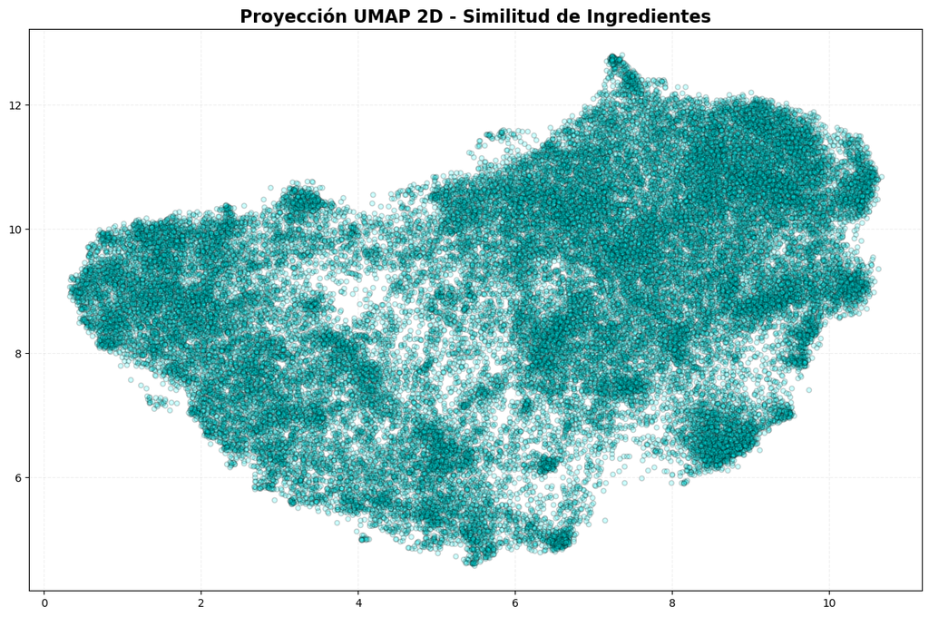

```python
visualizar_umap(df_final['umap_ingredients_x'], df_final['umap_ingredients_y'], "Proyección UMAP 2D - Similitud de Ingredientes")
```

**Análisis:** Compara la visualización obtenida con los **embeddings semánticos** (generados con MiniLM) y la nueva proyección obtenida a partir de la **representación one-hot** de los ingredientes. Describe las principales diferencias que observes entre ambas.

Justifica tu respuesta planteando una **hipótesis** sobre por qué los puntos se organizan de forma distinta en cada caso. Puedes reflexionar sobre qué tipo de información captura cada representación y cómo eso afecta a la estructura de los grupos observados.

En esta nueva proyección no vemos esas formaciones de "islas" que se daban con lo que podiamos intentar los datos según la densidad. En esta representación tenemos todos los datos, dispuestos en una misma nube, con alguna pequeña zona más densa que el resto.

Mi hipótesis es la siguiente:

En la primera visualización de los embeddings semánticos, al tener más tipos de datos con la reducción de dimensiones podía identificar patrones más sencillos si un plato es dulce, salado, un plato vegetariano, o del tipo que sea ya que tiene más datos que lo describen, por eso, aunque se reduzca su dimensionalidad podemos ver aún esos patrones.

En los ingredientes sin embargo tenemos un gran número de recetas y de ingredientes y unos 9 ingredientes de media por receta, esto nos genera una matriz one-hot prácticamente llena de 0s. Hay muchos ingredientes que abundan en muchas recetas, por ejemplo la sal o el aceite de oliva, ingredientes no representativos de una receta pero que suelen estar siempre. Esto nos genera mucha incertidumbre, al reducir dimensionalidad no podemos observar patrones medianamente claros por la naturaleza del ingrediente, si es un ingrediente primario, uno secundario, si viene en muchas cantidades.... Solo sabemos que está o no en una receta.

**Implementación:** A partir de la nueva representación **one-hot de ingredientes**, decide qué **algoritmo de clustering** utilizarías para agrupar las recetas. Explica si mantendrías el mismo algoritmo usado en el caso anterior o si elegirías otro, justificando tu decisión en función de la estructura observada en los datos.

Si el algoritmo elegido requiere una **métrica de similitud o distancia**, indica cuál utilizarías (por ejemplo, *Jaccard*, *coseno* o *euclídea*) y argumenta por qué resulta más adecuada para este tipo de datos binarios.

Ya que no vemos zonas de densidad definidas, no creo que la mejor opción sea volver a usar HDBSCAN. Teniendo en cuenta que estamos trabajando con una representación binaria, sería mejor usar un algoritmo de clustering jerárquico con la métrica de Jaccard.

Esta métrica resulta bastante útil en datos one-hot muy dispersos, porque solo tiene en cuenta la coincidencia en los valores “1” (ingredientes presentes) y ignora los ceros, que en este caso no aportan información. Así, la similitud entre recetas se basa realmente en los ingredientes que comparten, evitando que ingredientes muy comunes como la sal o el aceite distorsionen la distancia.

El clustering jerárquico, además, permite construir los grupos directamente a partir de esta matriz de distancias y ofrece una estructura más interpretable que otros métodos, sin necesidad de asumir formas esféricas o densidades concretas.

Ya que tarda mucho este método, se decide reducir el número de muestras

```python
df_sample = df_final.sample(n=5000, random_state=seed)
ingredients_onehot_sample = mlb_data_driven.fit_transform(
    df_sample['ingredients_normalized']
)
# Matríz binaria: ingredients_onehot
X = ingredients_onehot_sample

dist_jaccard = pdist(X, metric='jaccard')
```

```python
## Banco de pruebas
# Z = linkage(dist_jaccard, method='average')

# K_range = range(8, 21)
# best_k = None
# best_score = -1

# for k in K_range:
#     labels = fcluster(Z, k, criterion='maxclust')

#     # silhouette requiere >1 cluster
#     if len(np.unique(labels)) > 1:
#         score = silhouette_score(X, labels, metric='jaccard')
#         print(f"Para k={k}: {score}")

#         if score > best_score:
#             best_score = score
#             best_k = k

# print(f"Mejor K encontrado: {best_k} (silhouette={best_score:.4f})")
```

```python
Z = linkage(dist_jaccard, method='average')

labels_hier = fcluster(Z, 18, criterion='maxclust') - 1  # Que empiece en 0
df_sample["cluster_hier_jaccard"] = labels_hier
```

**Implementación:** Visualiza el conjunto de datos original (la proyección 2D obtenida con `UMAP`) coloreando cada punto según el **cluster** al que pertenece.

```python
def visualizar_clusters_sobre_umap(df, x_col='umap_ingredients_x', y_col='umap_ingredients_y',
                                    cluster_col='cluster_hier_jaccard',
                                    figsize=(14, 10), s=30, alpha=0.7):

    # Información de clusters
    unique_clusters = sorted(df[cluster_col].unique())
    n_clusters = len([c for c in unique_clusters if c != -1])
    n_outliers = (df[cluster_col] == -1).sum() if -1 in unique_clusters else 0


    # Tamaños de clusters
    cluster_sizes = df[cluster_col].value_counts().sort_index()
    for cluster_id in sorted(unique_clusters):
        if cluster_id != -1:
            size = cluster_sizes[cluster_id]
            pct = (size / len(df)) * 100

    # Preparar colores
    cmap = plt.colormaps.get_cmap('tab20')
    n_colors = 20

    colors = []
    for label in df[cluster_col]:
        if label == -1:
            colors.append('lightgray')  # Outliers
        else:
            colors.append(cmap(label % n_colors))

    # Crear figura
    fig, ax = plt.subplots(figsize=figsize)

    # Plotear outliers primero (si existen)
    if n_outliers > 0:
        outlier_mask = df[cluster_col] == -1
        ax.scatter(
            df.loc[outlier_mask, x_col],
            df.loc[outlier_mask, y_col],
            c='lightgray',
            s=s,
            alpha=alpha * 0.5,
            label='Outliers',
            edgecolors='none'
        )

    # Plotear cada cluster
    for cluster_id in sorted([c for c in unique_clusters if c != -1]):
        mask = df[cluster_col] == cluster_id
        ax.scatter(
            df.loc[mask, x_col],
            df.loc[mask, y_col],
            c=[cmap(cluster_id % n_colors)],
            s=s,
            alpha=alpha,
            label=f'Cluster {cluster_id}',
            edgecolors='white',
            linewidths=0.3
        )

    # Etiquetas y título
    ax.set_xlabel('UMAP Dimensión 1', fontsize=13)
    ax.set_ylabel('UMAP Dimensión 2', fontsize=13)
    ax.set_title(f'Proyección UMAP 2D - Clusters de Ingredientes (K={n_clusters})',
                 fontsize=15, fontweight='bold', pad=20)

    # Grid
    ax.grid(alpha=0.3, linestyle='--', linewidth=0.5)
    ax.set_axisbelow(True)

    ax.legend(bbox_to_anchor=(1.05, 1), loc='upper left',
                frameon=True, fontsize=9, ncol=1)

    plt.tight_layout()
    plt.show()
```

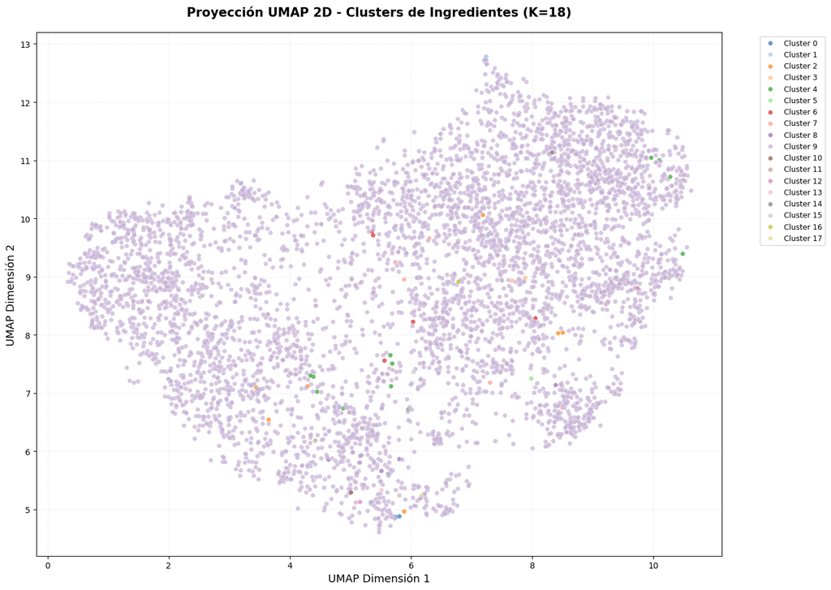

```python
visualizar_clusters_sobre_umap(df_sample)
```

**Implementación:** Para interpretar el clustering y comprobar su coherencia, selecciona los **10 clusters** más grandes y muestra, para cada uno:

1. Las **5 recetas más cercanas al centroide** del cluster (si el método lo define). Si no hay centroide, usa el *centroide empírico* (media del vector del cluster) o el *medoide* (receta con menor distancia media al resto). Emplea una métrica adecuada a la representación.
2. También, para cada cluster, muestra los **ingredientes más repetidos** del cluster (por ejemplo, top-3 o top-5), opcionalmente puedes indicar su frecuencia relativa para caracterizar el “tema” del grupo. Puedes agrupar y contar con utilidades tipo `Counter` o transformaciones previas del one-hot.

```python
analizar_top_clusters(df_sample, ingredients_onehot_sample, labels_hier)
```

```
CLUSTER 9 - Rank #1 - Tamaño: 4943 recetas

  Top 5 recetas más cercanas al centroide:

 RECETA #1 - Similitud con centroide: 0.6688
  - name: The Black- Eyed Peas Baked Squash
  - ingredients: ['yellow squash', 'eggs', 'whole wheat rolls', 'butter', 'sugar', 'salt', 'pepper', 'onion']
  - tags: ['60-minutes-or-less', 'time-to-make', 'course', 'main-ingredient', 'preparation', 'side-dishes', 'vegetables', 'dietary', 'squash']
  - search_terms: {'side'}

 RECETA #2 - Similitud con centroide: 0.6368
  - name: World Famous Churros
  - ingredients: ['butter', 'flour', 'salt', 'eggs', 'water', 'vegetable oil', 'cinnamon', 'brown sugar', 'sugar']
  - tags: ['weeknight', '30-minutes-or-less', 'time-to-make', 'course', 'main-ingredient', 'cuisine', 'preparation', 'occasion', 'breads', 'desserts', 'eggs-dairy', 'mexican', 'easy', 'holiday-event', 'kid-frie...
  - search_terms: {'mexican', 'dessert'}

 RECETA #3 - Similitud con centroide: 0.6288
  - name: Plecta Pancakes
  - ingredients: ['eggs', 'sugar', 'salt', 'flour', 'milk', 'butter']
  - tags: ['15-minutes-or-less', 'time-to-make', 'course', 'main-ingredient', 'cuisine', 'preparation', 'pancakes-and-waffles', 'breakfast', 'eggs-dairy', 'scandinavian', 'european', 'swedish', 'eggs', 'stove-t...
  - search_terms: {'breakfast'}

 RECETA #4 - Similitud con centroide: 0.6272
  - name: Skor Bar Sugar Cookies
  - ingredients: ['sugar', 'butter', 'vanilla', 'eggs', 'all-purpose flour', 'baking powder', 'baking soda', 'salt', 'skor english toffee bits']
  - tags: ['30-minutes-or-less', 'time-to-make', 'course', 'main-ingredient', 'cuisine', 'preparation', 'occasion', 'north-american', 'for-large-groups', 'hand-formed-cookies', 'desserts', 'canadian', 'oven', '...
  - search_terms: {'cookie', 'dessert'}

 RECETA #5 - Similitud con centroide: 0.6235
  - name: Southern Grits Rice-Style
  - ingredients: ['yellow corn grits', 'water', 'salt', 'butter']
  - tags: ['30-minutes-or-less', 'time-to-make', 'course', 'main-ingredient', 'cuisine', 'preparation', 'occasion', 'north-american', 'for-1-or-2', 'low-protein', 'healthy', '5-ingredients-or-less', 'very-low-c...
  - search_terms: {'low-calorie', 'low-sodium', 'healthy', 'low-carb', 'low-fat', 'southern', 'breakfast'}

CLUSTER 4 - Rank #2 - Tamaño: 13 recetas

  Top 5 recetas más cercanas al centroide:

 RECETA #1 - Similitud con centroide: 0.5669
  - name: Cranberry Walnut Feta Cheese Salad
```

[output cut: 114 more lines]

```
  - ingredients: ['peaches', 'boiling water', 'peaches', 'honey', 'almond extract', 'whipped topping', 'of fresh mint']
  - tags: ['30-minutes-or-less', 'time-to-make', 'course', 'main-ingredient', 'preparation', 'occasion', 'gelatin', 'desserts', 'eggs-dairy', 'fruit', 'easy', 'no-cook', 'refrigerator', 'beginner-cook', 'dinner...
  - search_terms: {'dessert', 'dinner'}

 RECETA #4 - Similitud con centroide: 0.5218
  - name: Vegan Oatmeal Burgers
  - ingredients: ['textured vegetable protein', 'quick-cooking rolled oats', 'dried basil leaves', 'dried oregano leaves', 'dried parsley flakes', 'dried garlic flakes', 'dried onion flakes', 'dry mustard', 'boiling w...
  - tags: ['30-minutes-or-less', 'time-to-make', 'course', 'preparation', 'occasion', 'main-dish', 'easy', 'vegan', 'vegetarian', 'dietary', 'comfort-food', 'taste-mood']
  - search_terms: {'dinner', 'vegetarian', 'vegan'}

 RECETA #5 - Similitud con centroide: 0.4851
  - name: Halloween Test Tube Shooters
  - ingredients: ['gelatin powder', 'boiling water', 'peaches', 'grape juice', 'hot chocolate powder']
  - tags: ['15-minutes-or-less', 'time-to-make', 'preparation', 'occasion', 'for-large-groups', 'healthy', 'holiday-event', 'low-fat', 'dietary', 'low-sodium', 'low-cholesterol', 'halloween', 'low-saturated-fat...
  - search_terms: {'healthy', 'low-calorie', 'low-fat', 'low-sodium'}
```

**Análisis:** Analiza los resultados del clustering y valora si los **clusters obtenidos tienen sentido** desde un punto de vista culinario. Observa los ingredientes más frecuentes y las recetas prototipo de cada grupo, e identifica si existe un patrón claro que relacione los platos entre sí.

En el primer cluster, el más poblado con prácticamente todos los datos podemos encontrar recetas especialmente con los ingredientes más comunes, huevos, agua, sal... Se puede catalogar como fallo por los tipos de datos, puede servir para ver ingredientes similares y muy usados pero contiene a casi todas las recetas.

El segundo cluster encontramos algunas recetas que no llevan los ingredientes principales y llevan otros menos comunes, encontramos ingredientes como la lechuga romana o cebolla roja.

En el tercer cluster encontramos recetas con ingredientes más dulces como el chocolate "semidulce".

En el cuarto, tenemos recetas que todas tienen jamón.

Los clusters si tienen sentido, al menos los de fuera del cluster más grande, son recetas con ingredientes similares que no suelen llevar ingredientes muy comunes.

**Análisis:** Compara los resultados obtenidos en este apartado (basados en la representación **one-hot de ingredientes**) con los del primer apartado (embeddings semánticos generados con **MiniLM**). Analiza si los grupos que aparecen son similares o diferentes, reflexiona sobre cómo influye el tipo de representación y explica las principales diferencias observadas.

Los resultados han sido algo mejor en la representación con los embeddings.

Aunque también encontrábamos un cluster grande y otros más especializados, estos últimos tenian más sentido que los cluster pequeños de los ingredientes, quizás modificando parámetros se podian haber diferenciado mejor los cluster de los embeddings.

Sin embargo, en la representación con la matriz one-hot de los ingredientes tenia el fallo inicial de la representación, una matriz con muchos ingredientes diferentes y recetas con pocos de estos ingredientes. Por ello después la representación ha salido algo mal, si que se han podido diferenciar algún cluster, pero no de la manera que se esperaba.

Los grupos conseguidos son diferentes, en el primero, los clusters pequeños eran recetas, de una misma temática, pero poco comunes. En los ingredientes eran recetas, con ingredientes poco comunes, pero que no usaban los ingredientes más comunes.

**Análisis:** Reflexiona sobre los posibles **casos de uso** de los dos enfoques de clustering aplicados:

- ¿Para qué tipo de problema o aplicación sería más útil el clustering basado en los **embeddings semánticos** (MiniLM)?
- ¿Y en qué tipo de situación resultaría más adecuado el clustering obtenido con la **representación one-hot de ingredientes**?

El clustering de los embeddings semánticos sería mejor si quisieras recetas similares. Tienes tus recetas, le aplicas el clustering y buscas una receta que a ti te gusta, por ejemplo una receta vegetariana que tenga arroz. Si hemos realizado bien el clustering y están bien los datos podriamos mirar dentro del mismo cluster de esa receta y encontraríamos recetas similares a las principales características de estas, así, si necesitas inspiración de una receta podrias mirar similares.

La representación one-hot de ingredientes en cambio creo que tendría un buen uso en la relación de ingredientes. Imaginemos que tenemos un cluster que contiene fresa, platano, chocolate y melocotón, ya que en varias recetas aparecían estos ingredientes o pares de ellos. Mirando el cluster podriamos buscar sustitutos o acompañantes a esos ingredientes. Que te apetece una receta chocolate, pero lleva fresas y no te gustan, podrias cambiarlo por alguno de los ingredientes del cluster, o, a una receta añadir ingredientes similares a otros que tengas.

**Análisis:** Piensa en **otras maneras de generar una representación** de las recetas, distintas de las vistas en la práctica (como los embeddings semánticos o los vectores one-hot de ingredientes). Describe brevemente cómo construirías esa nueva representación y qué tipo de información capturaría.

Podría haberse intentado una mejor representación one-hot, pero en vez de con ingredientes que había muchos diferentes, con los tags o los search terms, que debeería estar más normalizado hubiera sido una mejor aproximación. De esta manera podriamos diferenciar recetas según el tiempo, si tienen etiquetas de eso. Según si es un postre, una cena.. Las etiquetas pueden darnos algo más de juego que los ingredientes, al menos para representarlo de esta manera.